# Differential abundance analysis — Species level (Chinese cohort)

Anton

2026-06-01

```r
knitr::opts_knit$set(root.dir = rprojroot::find_rstudio_root_file())
knitr::opts_chunk$set(echo = TRUE, message = FALSE, warning = FALSE)
```

Species-level companion to `week21.Rmd`. Same filtered cohort (`Project.ID == "PRJNA422434"`), same methods, same direction convention (positive = T2D-enriched).

The diagnostic chunks (zero-inflation, right-skew, Q-Q) are skipped here because they were established at genus level — species-level data inherits and amplifies all three problems by sparsity. Method choice is therefore already justified; the focus of this Rmd is on whether the species-level results agree with or refine the genus-level headline.

| Resolution | n taxa | n samples |
| --- | --- | --- |
| Genus (week21.Rmd) | 58 | 359 |
| Species (this file) | ~173 | 359 |

## Loading of required libraries

```r
library(phyloseq)
library(vegan)
library(dplyr)
library(tibble)
library(tidyr)
library(stringr)
library(ggplot2)
library(ggh4x)
library(broom)
library(microbiome)
```

> *Taught in: W21 reference Rmd §1 “Loading of required libraries” (same phyloseq + vegan + tidyverse + broom + microbiome stack; mixed-model packages dropped as none are used).*

## Load and filter species data

```r
load("project/data/D003924_Diabetes_Mellitus,_T/species/D003924_phyloseq_updated_species.RData")
ps <- subset_samples(pylsq, Project.ID == "PRJNA422434")
rm(pylsq)

ps
```

```
## phyloseq-class experiment-level object
## otu_table()   OTU Table:         [ 173 taxa and 359 samples ]
## sample_data() Sample Data:       [ 359 samples by 12 sample variables ]
## tax_table()   Taxonomy Table:    [ 173 taxa by 7 taxonomic ranks ]
## phy_tree()    Phylogenetic Tree: [ 173 tips and 59 internal nodes ]
```

```r
table(sample_data(ps)$Disease.MESH.ID)
```

```
##
## D003924 D006262
##     187     172
```

```r
ntaxa(ps)
```

```
## [1] 173
```

> *Taught in: W21 reference Rmd §1 “Load and inspect the data” (`readRDS`/`load` the phyloseq object, check `ntaxa`, group table). Cohort `subset_samples` taught in W20-01.*

Expected: 187 T2D + 172 Healthy = 359 samples, ~173 species.

## Build relative-abundance long table

```r
ps_rel   <- transform_sample_counts(ps, function(x) x / sum(x))
otu_rel  <- as(otu_table(ps_rel), "matrix") %>% t() %>% as.data.frame()
meta_rel <- as(sample_data(ps_rel), "matrix") %>% as.data.frame()
tax_rel  <- as(tax_table(ps_rel), "matrix") %>% as.data.frame()
```

> *Taught in: W21 reference Rmd §2 “Visualise community composition” (`transform_sample_counts` to relative abundance, then extract OTU/meta/tax as data frames).*

```r
dat_rel <- otu_rel %>%
  rownames_to_column("sample_id") %>%
  pivot_longer(-sample_id, names_to = "taxon", values_to = "rel_abund") %>%
  left_join(meta_rel %>% rownames_to_column("sample_id"), by = "sample_id") %>%
  left_join(tax_rel  %>% rownames_to_column("taxon"),     by = "taxon")
```

> *Taught in: W21 reference Rmd §2 (the hidden chunk that builds the long `dat_rel` table joining abundance + metadata + taxonomy).*

## Community composition (top 20 species)

The full species panel is too wide for a stacked bar plot. We restrict to the 20 most abundant species and group the rest as “Other.”

> **Label note.** In this phyloseq object the `Species` column is populated with whatever rank MetaPhlAn could resolve the row to, prefixed by `s__`. That means it contains a mix of true species binomials (e.g. `s__Haemophilus parainfluenzae`), genus names (e.g. `s__Faecalibacterium`), and family-level placeholders (e.g. `s__Bacteroidaceae`). The unique row identifier is the full MetaPhlAn lineage stored in `taxon` (used for every join and every statistical test); the `Species` field is only a display label. Where two different `taxon` IDs share the same `Species` string, plot labels below are disambiguated with a `_1`, `_2` suffix (via `make.unique()`).

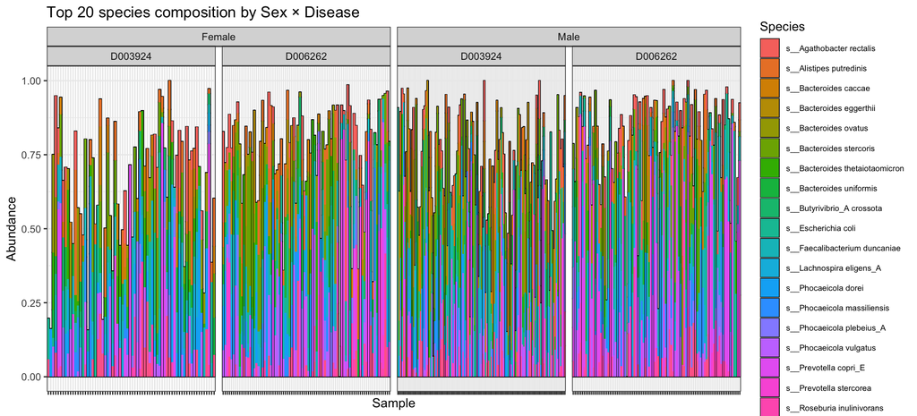

```r
top_n_species <- 20
top_species <- names(sort(taxa_sums(ps_rel), decreasing = TRUE)[1:top_n_species])
ps_top      <- prune_taxa(top_species, ps_rel)

plot_bar(ps_top, fill = "Species") +
  geom_bar(aes(fill = Species), stat = "identity", colour = NA) +
  facet_nested(~ Sex + Disease.MESH.ID, scales = "free_x") +
  theme_bw() +
  theme(axis.text.x = element_blank(),
        legend.text = element_text(size = 7)) +
  labs(title = "Top 20 species composition by Sex × Disease",
       fill = "Species")
```

> *Taught in: W21 reference Rmd §2 “Visualise community composition” (`plot_bar` + `facet_nested`). Restricting to the top-20 taxa with `taxa_sums` + `prune_taxa` is a project readability choice (the reference uses `tax_glom`; here the panel is already at the finest rank, so we cap the legend instead).*

# Univariate statistics

## Wilcoxon rank-sum test

```r
wilcox_results <- dat_rel %>%
  group_by(taxon, Genus, Species) %>%
  summarise(
    p_value      = wilcox.test(rel_abund ~ Disease.MESH.ID, exact = FALSE)$p.value,
    mean_T2D     = mean(rel_abund[Disease.MESH.ID == "D003924"]),
    mean_Healthy = mean(rel_abund[Disease.MESH.ID == "D006262"]),
    log2_fc      = log2((mean_T2D + 1e-6) / (mean_Healthy + 1e-6)),
    .groups = "drop"
  ) %>%
  mutate(q_value = p.adjust(p_value, method = "BH"))

head(wilcox_results, 10)
```

```
## # A tibble: 10 × 8
##    taxon   Genus          Species  p_value mean_T2D mean_Healthy log2_fc q_value
##    <chr>   <chr>          <chr>      <dbl>    <dbl>        <dbl>   <dbl>   <dbl>
##  1 100884  g__Coprobacil… s__Cop… NaN      0            0          0     NaN
##  2 100886  g__Catenibact… s__Cat… NaN      0            0          0     NaN
##  3 102684  g__Streptococ… s__Str…   0.300  0            0.000104  -6.71    0.502
##  4 103892  g__Veillonell… s__Vei…   0.340  0.000158     0          7.31    0.502
##  5 105841  g__Anaerostip… s__Ana… NaN      0            0          0     NaN
##  6 1099853 g__Coprobacter s__Cop…   0.176  0.000641     0          9.33    0.502
##  7 1118061 g__Rikenellac… s__Rik…   0.0544 0.00110      0         10.1     0.359
##  8 1203555 g__Acidaminoc… s__Aci… NaN      0            0          0     NaN
##  9 1211813 g__Alistipes_A s__Ali…   0.340  0.000354     0          8.47    0.502
## 10 1226323 g__Oscillibac… s__Osc…   0.959  0.000188     0.000136   0.460   0.959
```

> *Taught in: W21 reference Rmd §5 “Wilcoxon rank-sum test” (one `wilcox.test(... ~ group, exact = FALSE)` per taxon, group means, `log2_fc`, BH-adjusted `q_value`). Wilcoxon-over-t-test rationale: Alberdi reading §3; BH/FDR: §6 + W20-02.*

### Top T2D-depleted (Wilcoxon)

```r
wilcox_T2D_depleted <- wilcox_results %>%
  select(taxon, Genus, Species, mean_T2D, mean_Healthy, log2_fc, p_value, q_value) %>%
  arrange(log2_fc) %>%
  head(10)

wilcox_T2D_depleted
```

```
## # A tibble: 10 × 8
##    taxon  Genus            Species mean_T2D mean_Healthy log2_fc p_value q_value
##    <chr>  <chr>            <chr>      <dbl>        <dbl>   <dbl>   <dbl>   <dbl>
##  1 33043  g__Coprococcus   s__Cop…        0     0.000751   -9.55  0.141    0.502
##  2 658089 g__Anaerostipes  s__Ana…        0     0.000652   -9.35  0.0706   0.373
##  3 28126  g__Prevotella    s__Pre…        0     0.000628   -9.30  0.300    0.502
##  4 1535   g__Clostridium_A s__Clo…        0     0.000525   -9.04  0.300    0.502
##  5 384638 g__Bacteroides_F s__Bac…        0     0.000512   -9.00  0.300    0.502
##  6 36834  g__Clostridium   s__Clo…        0     0.000397   -8.64  0.300    0.502
##  7 457394 g__Phocaeicola   s__Pho…        0     0.000388   -8.60  0.300    0.502
##  8 469593 g__Phocaeicola   s__Pho…        0     0.000356   -8.48  0.300    0.502
##  9 548    g__Klebsiella    s__Kle…        0     0.000274   -8.10  0.141    0.502
## 10 39486  g__Dorea         s__Dor…        0     0.000234   -7.88  0.300    0.502
```

> *Taught in: W21 reference Rmd §5 (top table ordered by `log2_fc`, depleted tail).*

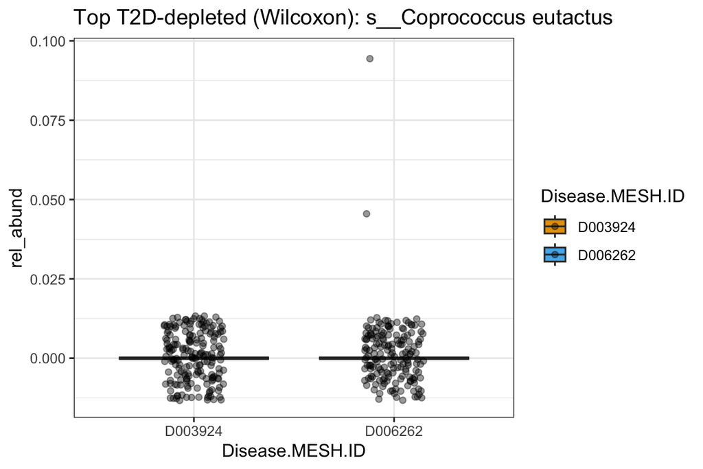

```r
top_taxon <- wilcox_T2D_depleted %>% slice(1) %>% pull(taxon)
top_label <- wilcox_T2D_depleted %>% slice(1) %>% pull(Species)

dat_rel %>%
  filter(taxon == top_taxon) %>%
  ggplot(aes(x = Disease.MESH.ID, y = rel_abund, fill = Disease.MESH.ID)) +
    geom_boxplot(outlier.shape = NA) +
    geom_jitter(width = 0.15, alpha = 0.4) +
    scale_fill_manual(values = c("D003924" = "#E69F00", "D006262" = "#56B4E9")) +
    theme_bw() +
    labs(title = paste("Top T2D-depleted (Wilcoxon):", top_label))
```

> *Taught in: W21 reference Rmd §5 (raw boxplot + jitter of the top hit as a visual check of test direction).*

### Top T2D-enriched (Wilcoxon)

```r
wilcox_T2D_enriched <- wilcox_results %>%
  select(taxon, Genus, Species, mean_T2D, mean_Healthy, log2_fc, p_value, q_value) %>%
  arrange(-log2_fc) %>%
  head(10)

wilcox_T2D_enriched
```

```
## # A tibble: 10 × 8
##    taxon   Genus           Species mean_T2D mean_Healthy log2_fc p_value q_value
##    <chr>   <chr>           <chr>      <dbl>        <dbl>   <dbl>   <dbl>   <dbl>
##  1 1604    g__Lactobacill… s__Lac… 0.00465             0   12.2   0.0312   0.323
##  2 626932  g__Alistipes_A  s__Ali… 0.00187             0   10.9   0.0312   0.323
##  3 97478   g__Limosilacto… s__Lim… 0.00162             0   10.7   0.0106   0.182
##  4 45851   g__Butyrivibri… s__But… 0.00160             0   10.6   0.340    0.502
##  5 328812  g__Parabactero… s__Par… 0.00141             0   10.5   0.0964   0.393
##  6 1596    g__Lactobacill… s__Lac… 0.00112             0   10.1   0.340    0.502
##  7 33959   g__Lactobacill… s__Lac… 0.00111             0   10.1   0.0964   0.393
##  8 665956  g__Ruthenibact… s__Rut… 0.00111             0   10.1   0.0544   0.359
##  9 1118061 g__Rikenellace… s__Rik… 0.00110             0   10.1   0.0544   0.359
## 10 626935  g__Collinsella  s__Col… 0.000918            0    9.84  0.340    0.502
```

> *Taught in: W21 reference Rmd §5 (top table ordered by `log2_fc`, enriched tail).*

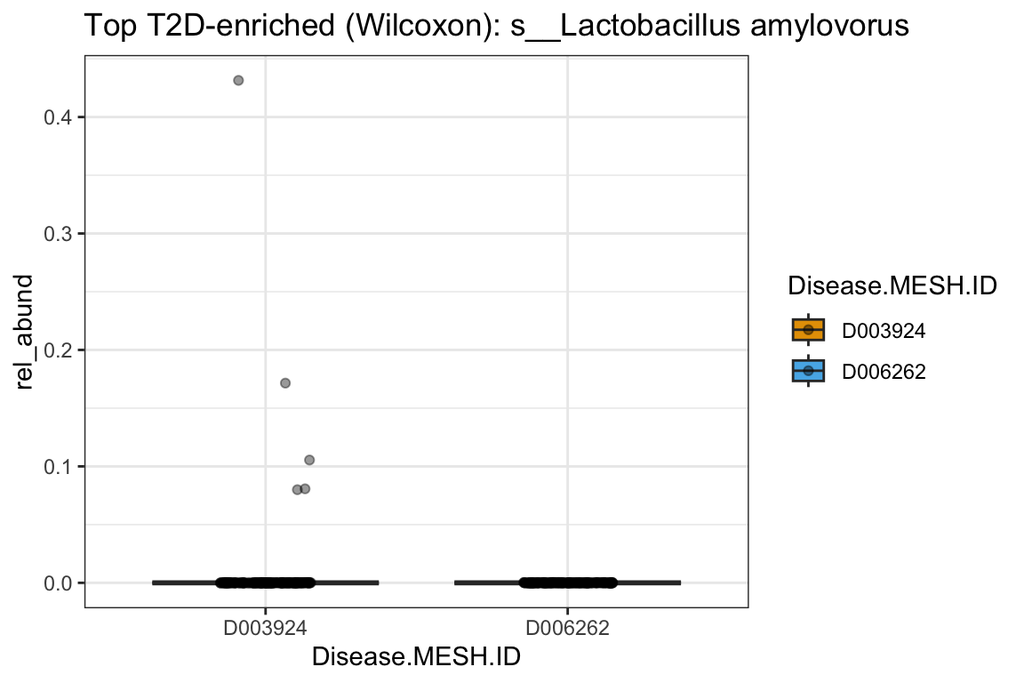

```r
top_taxon <- wilcox_T2D_enriched %>% slice(1) %>% pull(taxon)
top_label <- wilcox_T2D_enriched %>% slice(1) %>% pull(Species)

dat_rel %>%
  filter(taxon == top_taxon) %>%
  ggplot(aes(x = Disease.MESH.ID, y = rel_abund, fill = Disease.MESH.ID)) +
    geom_boxplot(outlier.shape = NA) +
    geom_jitter(width = 0.15, alpha = 0.4) +
    scale_fill_manual(values = c("D003924" = "#E69F00", "D006262" = "#56B4E9")) +
    theme_bw() +
    labs(title = paste("Top T2D-enriched (Wilcoxon):", top_label))
```

> *Taught in: W21 reference Rmd §5 (raw boxplot + jitter of the top enriched hit).*

### Volcano plot — Wilcoxon

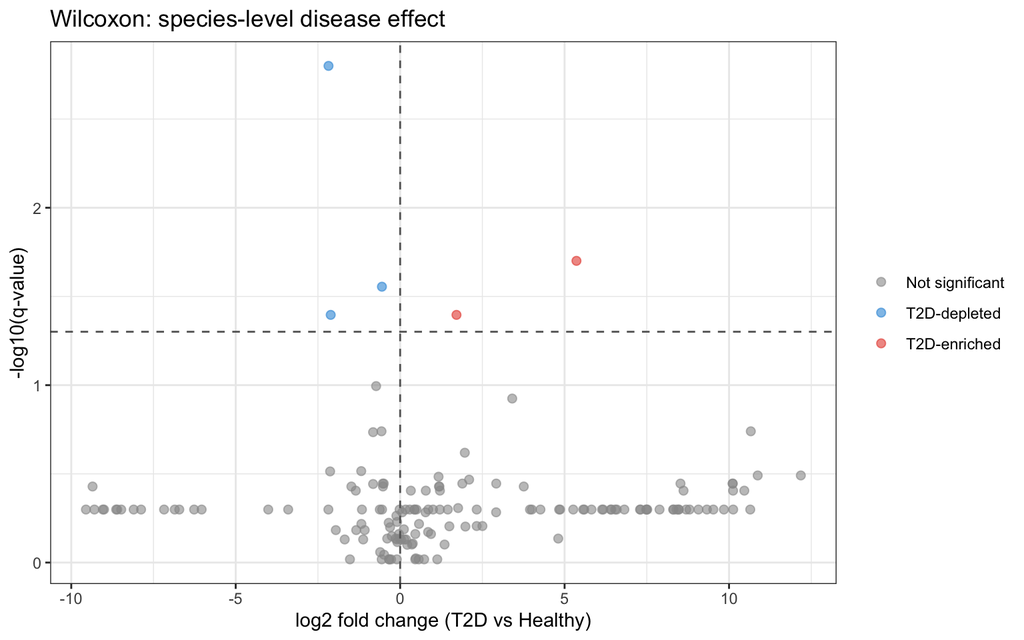

```r
wilcox_results %>%
  mutate(
    neg_log10_q = -log10(q_value),
    direction = case_when(
      q_value < 0.05 & log2_fc > 0 ~ "T2D-enriched",
      q_value < 0.05 & log2_fc < 0 ~ "T2D-depleted",
      TRUE                         ~ "Not significant"
    )
  ) %>%
  ggplot(aes(x = log2_fc, y = neg_log10_q, color = direction)) +
    geom_point(alpha = 0.6, size = 2) +
    scale_color_manual(values = c("T2D-enriched" = "#E74C3C",
                                  "T2D-depleted" = "#3498DB",
                                  "Not significant" = "grey60")) +
    geom_hline(yintercept = -log10(0.05), linetype = "dashed", color = "grey40") +
    geom_vline(xintercept = 0, linetype = "dashed", color = "grey40") +
    labs(x = "log2 fold change (T2D vs Healthy)",
         y = "-log10(q-value)", color = NULL,
         title = "Wilcoxon: species-level disease effect") +
    theme_bw()
```

> *Taught in: W21 reference Rmd §5 (volcano plot: `log2_fc` on x, `-log10(q)` on y, q < 0.05 line).*

### Bar chart — Wilcoxon top significant taxa by q-value

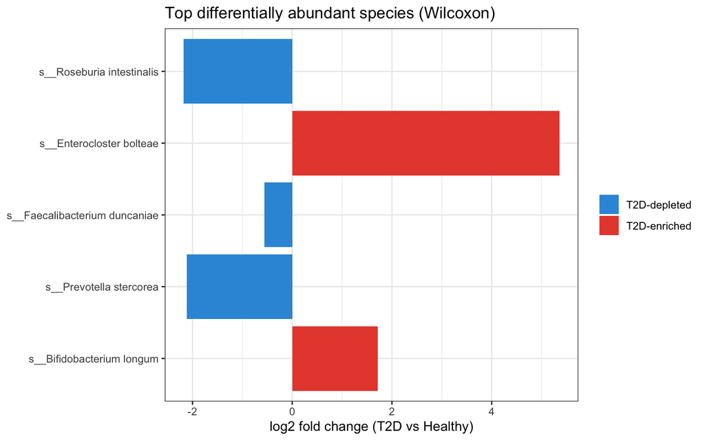

```r
bind_rows(
  wilcox_results %>% filter(q_value < 0.05) %>% arrange(log2_fc)  %>% head(10),
  wilcox_results %>% filter(q_value < 0.05) %>% arrange(-log2_fc) %>% head(10)
) %>%
  distinct() %>%
  mutate(
    label     = make.unique(as.character(Species), sep = "_"),
    direction = ifelse(log2_fc > 0, "T2D-enriched", "T2D-depleted")
  ) %>%
  ggplot(aes(x = reorder(label, -q_value), y = log2_fc, fill = direction)) +
    geom_col() +
    coord_flip() +
    scale_fill_manual(values = c("T2D-enriched" = "#E74C3C",
                                 "T2D-depleted" = "#3498DB")) +
    labs(x = NULL, y = "log2 fold change (T2D vs Healthy)", fill = NULL,
         title = "Top differentially abundant species (Wilcoxon)") +
    theme_bw()
```

> *Taught in: W21 reference Rmd §5 (bar chart of top significant taxa, top-10 each side, ordered by q-value).*

## GLM (unadjusted)

```r
glm_disease_results <- dat_rel %>%
  mutate(Disease.MESH.ID = factor(Disease.MESH.ID, levels = c("D006262", "D003924"))) %>%
  group_by(taxon, Genus, Species) %>%
  group_modify(~ {
    fit <- glm(log10(rel_abund + 1e-6) ~ Disease.MESH.ID,
               data = .x, family = gaussian())
    broom::tidy(fit)
  }) %>%
  ungroup() %>%
  filter(term == "Disease.MESH.IDD003924") %>%
  mutate(
    q_value = p.adjust(p.value, method = "BH"),
    fold_change_T2D_vs_Healthy = 10^estimate
  )
```

> *Taught in: W21 reference Rmd §6 “log-transformed linear models” (`glm(log10(rel_abund + 1e-6) ~ group)` per taxon, BH-adjusted, `10^estimate` = fold change). Logs + pseudocount: Alberdi reading §4; linear models: §5.*

### Top T2D-depleted (GLM unadjusted)

```r
glm_T2D_depleted <- glm_disease_results %>%
  select(taxon, Genus, Species, estimate, fold_change_T2D_vs_Healthy,
         std.error, statistic, p.value, q_value) %>%
  arrange(fold_change_T2D_vs_Healthy) %>%
  head(10)

glm_T2D_depleted
```

```
## # A tibble: 10 × 9
##    taxon  Genus      Species estimate fold_change_T2D_vs_H…¹ std.error statistic
##    <chr>  <chr>      <chr>      <dbl>                  <dbl>     <dbl>     <dbl>
##  1 853    g__Faecal… s__Fae…   -0.809                  0.155     0.246     -3.29
##  2 166486 g__Rosebu… s__Ros…   -0.771                  0.170     0.170     -4.54
##  3 39491  g__Agatho… s__Aga…   -0.713                  0.193     0.236     -3.02
##  4 821    g__Phocae… s__Pho…   -0.635                  0.232     0.252     -2.51
##  5 360807 g__Rosebu… s__Ros…   -0.588                  0.258     0.217     -2.71
##  6 363265 g__Prevot… s__Pre…   -0.517                  0.304     0.156     -3.32
##  7 165179 g__Prevot… s__Pre…   -0.419                  0.381     0.248     -1.69
##  8 310297 g__Phocae… s__Pho…   -0.392                  0.406     0.213     -1.83
##  9 310298 g__Butyri… s__But…   -0.356                  0.441     0.186     -1.92
## 10 39485  g__Lachno… s__Lac…   -0.301                  0.500     0.224     -1.34
## # ℹ abbreviated name: ¹fold_change_T2D_vs_Healthy
## # ℹ 2 more variables: p.value <dbl>, q_value <dbl>
```

> *Taught in: W21 reference Rmd §6 (top GLM table, depleted tail, sorted by fold change ascending).*

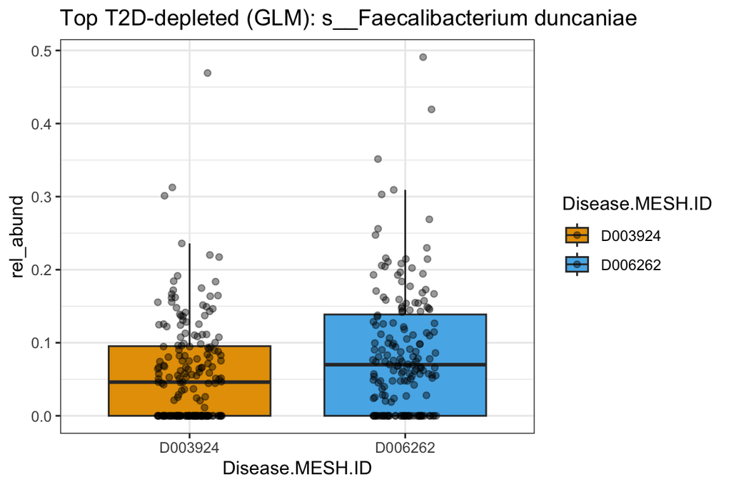

```r
top_taxon <- glm_T2D_depleted %>% slice(1) %>% pull(taxon)
top_label <- glm_T2D_depleted %>% slice(1) %>% pull(Species)

dat_rel %>%
  filter(taxon == top_taxon) %>%
  ggplot(aes(x = Disease.MESH.ID, y = rel_abund, fill = Disease.MESH.ID)) +
    geom_boxplot(outlier.shape = NA) +
    geom_jitter(width = 0.15, alpha = 0.4) +
    scale_fill_manual(values = c("D003924" = "#E69F00", "D006262" = "#56B4E9")) +
    theme_bw() +
    labs(title = paste("Top T2D-depleted (GLM):", top_label))
```

> *Taught in: W21 reference Rmd §6 (raw-data boxplot of the top GLM hit as a visual check of direction).*

### Top T2D-enriched (GLM unadjusted)

```r
glm_T2D_enriched <- glm_disease_results %>%
  select(taxon, Genus, Species, estimate, fold_change_T2D_vs_Healthy,
         std.error, statistic, p.value, q_value) %>%
  arrange(-fold_change_T2D_vs_Healthy) %>%
  head(10)

glm_T2D_enriched
```

```
## # A tibble: 10 × 9
##    taxon  Genus      Species estimate fold_change_T2D_vs_H…¹ std.error statistic
##    <chr>  <chr>      <chr>      <dbl>                  <dbl>     <dbl>     <dbl>
##  1 216816 g__Bifido… s__Bif…    0.529                   3.38    0.163       3.24
##  2 208479 g__Entero… s__Ent…    0.469                   2.94    0.124       3.79
##  3 46503  g__Rumino… s__Rum…    0.397                   2.50    0.187       2.12
##  4 357276 g__Phocae… s__Pho…    0.395                   2.48    0.226       1.75
##  5 40518  g__Rumino… s__Rum…    0.361                   2.30    0.224       1.61
##  6 47678  g__Bacter… s__Bac…    0.351                   2.24    0.221       1.58
##  7 239935 g__Akkerm… s__Akk…    0.325                   2.12    0.132       2.46
##  8 562    g__Escher… s__Esc…    0.279                   1.90    0.244       1.14
##  9 1685   g__Bifido… s__Bif…    0.275                   1.88    0.0985      2.79
## 10 246787 g__Bacter… s__Bac…    0.267                   1.85    0.149       1.79
## # ℹ abbreviated name: ¹fold_change_T2D_vs_Healthy
## # ℹ 2 more variables: p.value <dbl>, q_value <dbl>
```

> *Taught in: W21 reference Rmd §6 (top GLM table, enriched tail, sorted by fold change descending).*

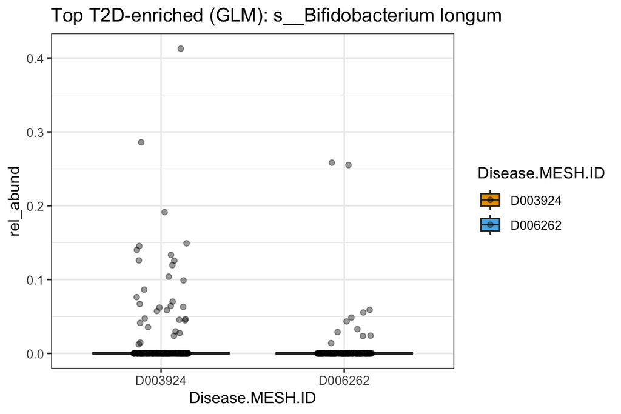

```r
top_taxon <- glm_T2D_enriched %>% slice(1) %>% pull(taxon)
top_label <- glm_T2D_enriched %>% slice(1) %>% pull(Species)

dat_rel %>%
  filter(taxon == top_taxon) %>%
  ggplot(aes(x = Disease.MESH.ID, y = rel_abund, fill = Disease.MESH.ID)) +
    geom_boxplot(outlier.shape = NA) +
    geom_jitter(width = 0.15, alpha = 0.4) +
    scale_fill_manual(values = c("D003924" = "#E69F00", "D006262" = "#56B4E9")) +
    theme_bw() +
    labs(title = paste("Top T2D-enriched (GLM):", top_label))
```

> *Taught in: W21 reference Rmd §6 (raw-data boxplot of the top enriched GLM hit).*

### Volcano plot — GLM unadjusted

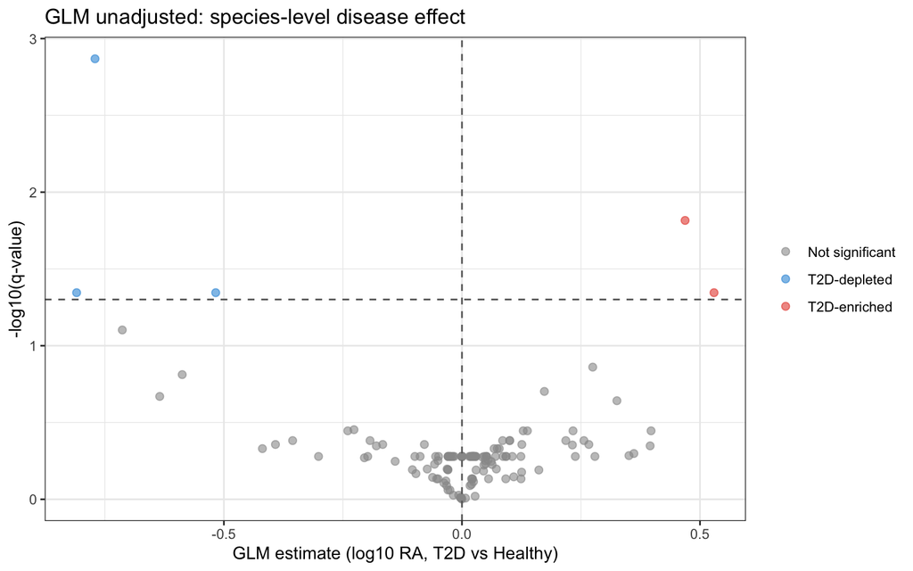

```r
glm_disease_results %>%
  mutate(
    neg_log10_q = -log10(q_value),
    direction = case_when(
      q_value < 0.05 & estimate > 0 ~ "T2D-enriched",
      q_value < 0.05 & estimate < 0 ~ "T2D-depleted",
      TRUE                          ~ "Not significant"
    )
  ) %>%
  ggplot(aes(x = estimate, y = neg_log10_q, color = direction)) +
    geom_point(alpha = 0.6, size = 2) +
    scale_color_manual(values = c("T2D-enriched" = "#E74C3C",
                                  "T2D-depleted" = "#3498DB",
                                  "Not significant" = "grey60")) +
    geom_hline(yintercept = -log10(0.05), linetype = "dashed", color = "grey40") +
    geom_vline(xintercept = 0, linetype = "dashed", color = "grey40") +
    labs(x = "GLM estimate (log10 RA, T2D vs Healthy)",
         y = "-log10(q-value)", color = NULL,
         title = "GLM unadjusted: species-level disease effect") +
    theme_bw()
```

> *Taught in: W21 reference Rmd §6 (GLM volcano plot using the model estimate as the effect-size axis).*

### Bar chart — GLM top significant taxa by q-value

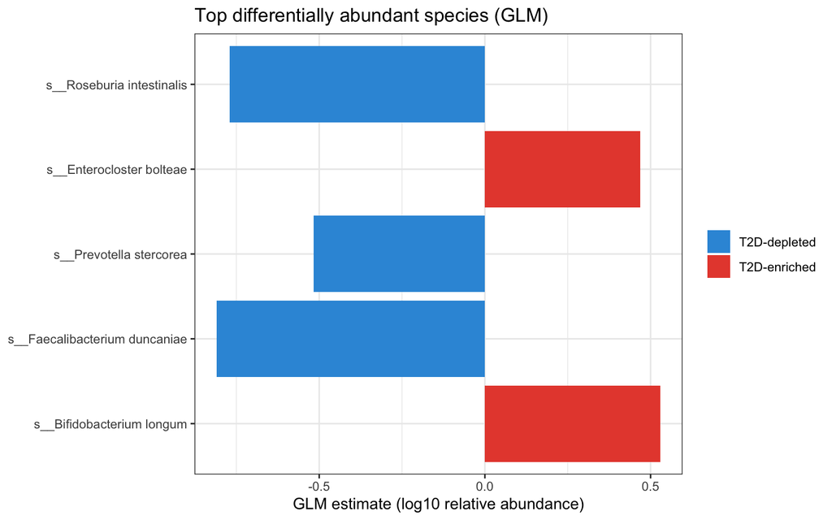

```r
bind_rows(
  glm_disease_results %>% filter(q_value < 0.05) %>% arrange(estimate)  %>% head(10),
  glm_disease_results %>% filter(q_value < 0.05) %>% arrange(-estimate) %>% head(10)
) %>%
  distinct() %>%
  mutate(
    label     = make.unique(as.character(Species), sep = "_"),
    direction = ifelse(estimate > 0, "T2D-enriched", "T2D-depleted")
  ) %>%
  ggplot(aes(x = reorder(label, -q_value), y = estimate, fill = direction)) +
    geom_col() +
    coord_flip() +
    scale_fill_manual(values = c("T2D-enriched" = "#E74C3C",
                                 "T2D-depleted" = "#3498DB")) +
    labs(x = NULL, y = "GLM estimate (log10 relative abundance)", fill = NULL,
         title = "Top differentially abundant species (GLM)") +
    theme_bw()
```

> *Taught in: W21 reference Rmd §6 (bar chart of top significant taxa from the GLM, top-10 each side, ordered by q-value).*

## Primary adjusted model — Sex + Host.age (n = 359)

```r
glm_disease_adjusted_sex_results <- dat_rel %>%
  mutate(
    Disease.MESH.ID = factor(Disease.MESH.ID, levels = c("D006262", "D003924")),
    Sex             = factor(Sex,             levels = c("Female", "Male")),
    Host.age        = as.numeric(Host.age)
  ) %>%
  group_by(taxon, Genus, Species) %>%
  group_modify(~ {
    fit <- glm(log10(rel_abund + 1e-6) ~ Disease.MESH.ID + Sex + Host.age,
               data = .x, family = gaussian())
    broom::tidy(fit)
  }) %>%
  ungroup() %>%
  filter(term == "Disease.MESH.IDD003924") %>%
  mutate(
    q_value = p.adjust(p.value, method = "BH"),
    fold_change_T2D_vs_Healthy_adj = 10^estimate
  )
```

> *Taught in: W21 reference Rmd §7 “Adjust the linear model” (same GLM with covariates; teacher uses `status`, here `Sex` + `Host.age`). Covariate adjustment: Alberdi reading §5. Sex/Age are the only complete, polymorphic metadata variables in this cohort.*

### Top T2D-depleted (GLM adj. Sex + Age)

```r
glm_adj_T2D_depleted <- glm_disease_adjusted_sex_results %>%
  select(taxon, Genus, Species, estimate, fold_change_T2D_vs_Healthy_adj,
         std.error, statistic, p.value, q_value) %>%
  arrange(fold_change_T2D_vs_Healthy_adj) %>%
  head(10)

glm_adj_T2D_depleted
```

```
## # A tibble: 10 × 9
##    taxon  Genus      Species estimate fold_change_T2D_vs_H…¹ std.error statistic
##    <chr>  <chr>      <chr>      <dbl>                  <dbl>     <dbl>     <dbl>
##  1 166486 g__Rosebu… s__Ros…   -0.742                  0.181     0.186     -4.00
##  2 853    g__Faecal… s__Fae…   -0.715                  0.193     0.268     -2.67
##  3 39491  g__Agatho… s__Aga…   -0.638                  0.230     0.258     -2.47
##  4 360807 g__Rosebu… s__Ros…   -0.600                  0.251     0.237     -2.53
##  5 310297 g__Phocae… s__Pho…   -0.579                  0.264     0.232     -2.49
##  6 363265 g__Prevot… s__Pre…   -0.434                  0.368     0.169     -2.56
##  7 310298 g__Butyri… s__But…   -0.371                  0.426     0.203     -1.83
##  8 821    g__Phocae… s__Pho…   -0.330                  0.468     0.273     -1.21
##  9 165179 g__Prevot… s__Pre…   -0.304                  0.496     0.270     -1.13
## 10 387090 g__Phocae… s__Pho…   -0.300                  0.501     0.146     -2.05
## # ℹ abbreviated name: ¹fold_change_T2D_vs_Healthy_adj
## # ℹ 2 more variables: p.value <dbl>, q_value <dbl>
```

> *Taught in: W21 reference Rmd §7 (adjusted top table, depleted tail).*

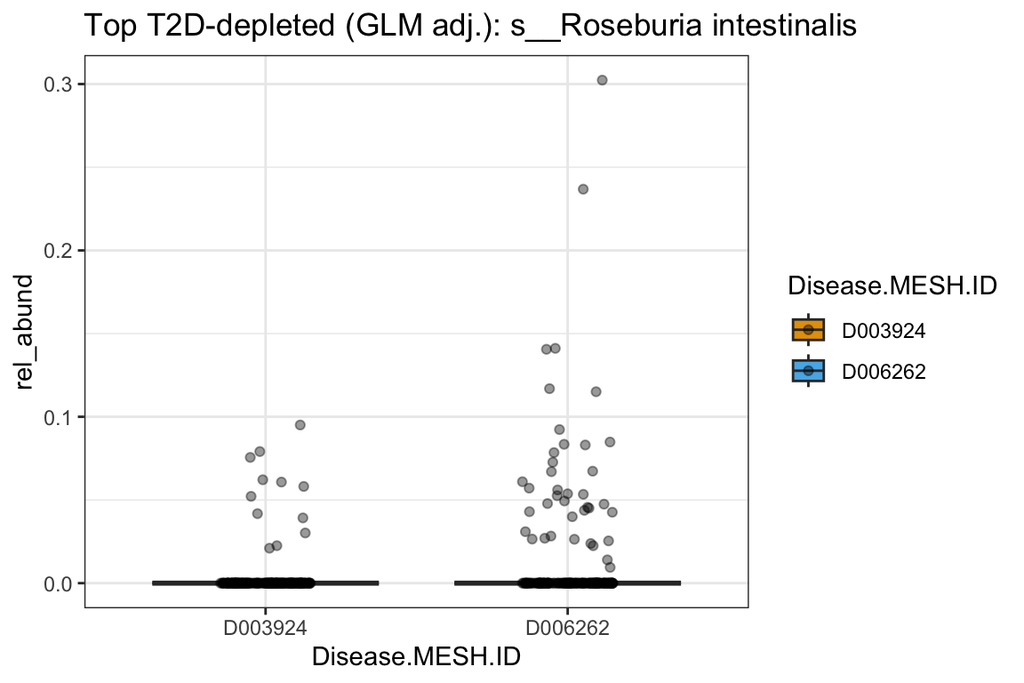

```r
top_taxon <- glm_adj_T2D_depleted %>% slice(1) %>% pull(taxon)
top_label <- glm_adj_T2D_depleted %>% slice(1) %>% pull(Species)

dat_rel %>%
  filter(taxon == top_taxon) %>%
  ggplot(aes(x = Disease.MESH.ID, y = rel_abund, fill = Disease.MESH.ID)) +
    geom_boxplot(outlier.shape = NA) +
    geom_jitter(width = 0.15, alpha = 0.4) +
    scale_fill_manual(values = c("D003924" = "#E69F00", "D006262" = "#56B4E9")) +
    theme_bw() +
    labs(title = paste("Top T2D-depleted (GLM adj.):", top_label))
```

> *Taught in: W21 reference Rmd §7 (raw boxplot of the top adjusted hit; the plot is marginal over Sex/Age, so it is a visual check, not a replacement for the adjusted model).*

### Top T2D-enriched (GLM adj. Sex + Age)

```r
glm_adj_T2D_enriched <- glm_disease_adjusted_sex_results %>%
  select(taxon, Genus, Species, estimate, fold_change_T2D_vs_Healthy_adj,
         std.error, statistic, p.value, q_value) %>%
  arrange(-fold_change_T2D_vs_Healthy_adj) %>%
  head(10)

glm_adj_T2D_enriched
```

```
## # A tibble: 10 × 9
##    taxon  Genus      Species estimate fold_change_T2D_vs_H…¹ std.error statistic
##    <chr>  <chr>      <chr>      <dbl>                  <dbl>     <dbl>     <dbl>
##  1 208479 g__Entero… s__Ent…    0.463                   2.90     0.135      3.42
##  2 46503  g__Rumino… s__Rum…    0.416                   2.60     0.205      2.03
##  3 357276 g__Phocae… s__Pho…    0.398                   2.50     0.244      1.63
##  4 39492  g__Rumini… s__Rum…    0.394                   2.48     0.141      2.80
##  5 216816 g__Bifido… s__Bif…    0.356                   2.27     0.177      2.01
##  6 246787 g__Bacter… s__Bac…    0.340                   2.19     0.162      2.10
##  7 47678  g__Bacter… s__Bac…    0.332                   2.15     0.242      1.37
##  8 239935 g__Akkerm… s__Akk…    0.303                   2.01     0.145      2.09
##  9 40518  g__Rumino… s__Rum…    0.299                   1.99     0.245      1.22
## 10 28116  g__Bacter… s__Bac…    0.272                   1.87     0.228      1.19
## # ℹ abbreviated name: ¹fold_change_T2D_vs_Healthy_adj
## # ℹ 2 more variables: p.value <dbl>, q_value <dbl>
```

> *Taught in: W21 reference Rmd §7 (adjusted top table, enriched tail).*

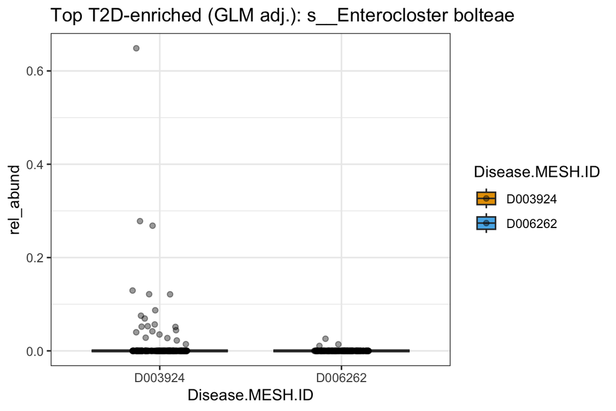

```r
top_taxon <- glm_adj_T2D_enriched %>% slice(1) %>% pull(taxon)
top_label <- glm_adj_T2D_enriched %>% slice(1) %>% pull(Species)

dat_rel %>%
  filter(taxon == top_taxon) %>%
  ggplot(aes(x = Disease.MESH.ID, y = rel_abund, fill = Disease.MESH.ID)) +
    geom_boxplot(outlier.shape = NA) +
    geom_jitter(width = 0.15, alpha = 0.4) +
    scale_fill_manual(values = c("D003924" = "#E69F00", "D006262" = "#56B4E9")) +
    theme_bw() +
    labs(title = paste("Top T2D-enriched (GLM adj.):", top_label))
```

> *Taught in: W21 reference Rmd §7 (raw boxplot of the top enriched adjusted hit; marginal over Sex/Age).*

### Volcano plot — GLM adjusted

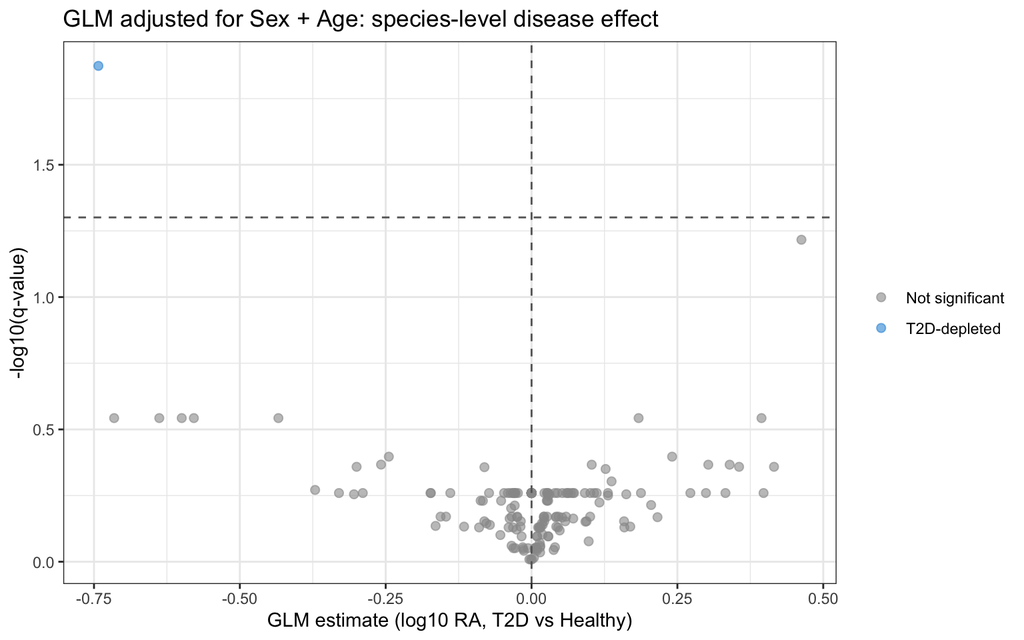

```r
glm_disease_adjusted_sex_results %>%
  mutate(
    neg_log10_q = -log10(q_value),
    direction = case_when(
      q_value < 0.05 & estimate > 0 ~ "T2D-enriched",
      q_value < 0.05 & estimate < 0 ~ "T2D-depleted",
      TRUE                          ~ "Not significant"
    )
  ) %>%
  ggplot(aes(x = estimate, y = neg_log10_q, color = direction)) +
    geom_point(alpha = 0.6, size = 2) +
    scale_color_manual(values = c("T2D-enriched" = "#E74C3C",
                                  "T2D-depleted" = "#3498DB",
                                  "Not significant" = "grey60")) +
    geom_hline(yintercept = -log10(0.05), linetype = "dashed", color = "grey40") +
    geom_vline(xintercept = 0, linetype = "dashed", color = "grey40") +
    labs(x = "GLM estimate (log10 RA, T2D vs Healthy)",
         y = "-log10(q-value)", color = NULL,
         title = "GLM adjusted for Sex + Age: species-level disease effect") +
    theme_bw()
```

> *Taught in: W21 reference Rmd §7 (adjusted-model volcano plot).*

### Bar chart — GLM adjusted top significant taxa by q-value

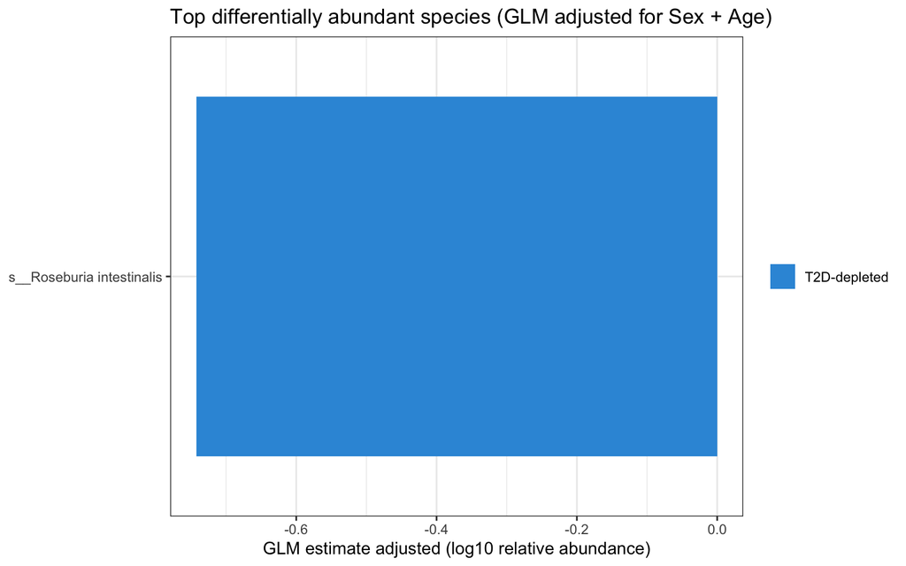

```r
bind_rows(
  glm_disease_adjusted_sex_results %>% filter(q_value < 0.05) %>% arrange(estimate)  %>% head(10),
  glm_disease_adjusted_sex_results %>% filter(q_value < 0.05) %>% arrange(-estimate) %>% head(10)
) %>%
  distinct() %>%
  mutate(
    label     = make.unique(as.character(Species), sep = "_"),
    direction = ifelse(estimate > 0, "T2D-enriched", "T2D-depleted")
  ) %>%
  ggplot(aes(x = reorder(label, -q_value), y = estimate, fill = direction)) +
    geom_col() +
    coord_flip() +
    scale_fill_manual(values = c("T2D-enriched" = "#E74C3C",
                                 "T2D-depleted" = "#3498DB")) +
    labs(x = NULL, y = "GLM estimate adjusted (log10 relative abundance)", fill = NULL,
         title = "Top differentially abundant species (GLM adjusted for Sex + Age)") +
    theme_bw()
```

> *Taught in: W21 reference Rmd §7 (bar chart of top adjusted significant taxa, top-10 each side, ordered by q-value).*

## Compositional analysis with CLR transformation

```r
ps_clr <- transform_sample_counts(ps, function(x) {
  x <- x + 1e-9
  log(x) - mean(log(x))
})
otu_clr  <- as(otu_table(ps_clr), "matrix") %>% t() %>% as.data.frame()
meta_clr <- as(sample_data(ps_clr), "matrix") %>% as.data.frame()
tax_clr  <- as(tax_table(ps_clr), "matrix") %>% as.data.frame()
```

> *Taught in: W21 reference Rmd §9 “Compositional analysis with CLR transformation” (the CLR closure: pseudocount + `log(x) - mean(log(x))`). Why CLR for closed relative-abundance data: Alberdi reading §7.*

```r
dat_clr <- otu_clr %>%
  rownames_to_column("sample_id") %>%
  pivot_longer(-sample_id, names_to = "taxon", values_to = "clr") %>%
  left_join(meta_clr %>% rownames_to_column("sample_id"), by = "sample_id") %>%
  left_join(tax_clr  %>% rownames_to_column("taxon"),     by = "taxon")
```

> *Taught in: W21 reference Rmd §9 (the hidden chunk reshaping CLR values into long `dat_clr`).*

```r
clr_disease_adjusted_sex_results <- dat_clr %>%
  mutate(
    Disease.MESH.ID = factor(Disease.MESH.ID, levels = c("D006262", "D003924")),
    Sex             = factor(Sex,             levels = c("Female", "Male")),
    Host.age        = as.numeric(Host.age)
  ) %>%
  group_by(taxon, Genus, Species) %>%
  group_modify(~ {
    fit <- lm(clr ~ Disease.MESH.ID + Sex + Host.age, data = .x)
    broom::tidy(fit)
  }) %>%
  ungroup() %>%
  filter(term == "Disease.MESH.IDD003924") %>%
  mutate(q_value = p.adjust(p.value, method = "BH"))
```

> *Taught in: W21 reference Rmd §9 (`lm(clr ~ group + covariate)` per taxon, BH-adjusted; teacher adjusts for `status`, here `Sex` + `Host.age`).*

### Top T2D-depleted (CLR)

```r
clr_T2D_depleted <- clr_disease_adjusted_sex_results %>%
  select(taxon, Genus, Species, estimate, std.error, statistic, p.value, q_value) %>%
  arrange(estimate) %>%
  head(10)

clr_T2D_depleted
```

```
## # A tibble: 10 × 8
##    taxon  Genus             Species estimate std.error statistic p.value q_value
##    <chr>  <chr>             <chr>      <dbl>     <dbl>     <dbl>   <dbl>   <dbl>
##  1 166486 g__Roseburia      s__Ros…    -2.74     0.687     -3.99 7.87e-5  0.0136
##  2 853    g__Faecalibacter… s__Fae…    -2.63     0.971     -2.70 7.19e-3  0.274
##  3 39491  g__Agathobacter   s__Aga…    -2.38     0.935     -2.55 1.12e-2  0.274
##  4 360807 g__Roseburia      s__Ros…    -2.26     0.874     -2.58 1.03e-2  0.274
##  5 310297 g__Phocaeicola    s__Pho…    -2.10     0.839     -2.51 1.27e-2  0.274
##  6 363265 g__Prevotella     s__Pre…    -1.54     0.605     -2.54 1.14e-2  0.274
##  7 310298 g__Butyrivibrio_A s__But…    -1.37     0.734     -1.86 6.36e-2  0.500
##  8 821    g__Phocaeicola    s__Pho…    -1.23     0.995     -1.24 2.17e-1  0.710
##  9 39485  g__Lachnospira    s__Lac…    -1.09     0.893     -1.22 2.25e-1  0.710
## 10 387090 g__Phocaeicola    s__Pho…    -1.08     0.523     -2.07 3.92e-2  0.425
```

> *Taught in: W21 reference Rmd §9 (CLR top table, depleted tail).*

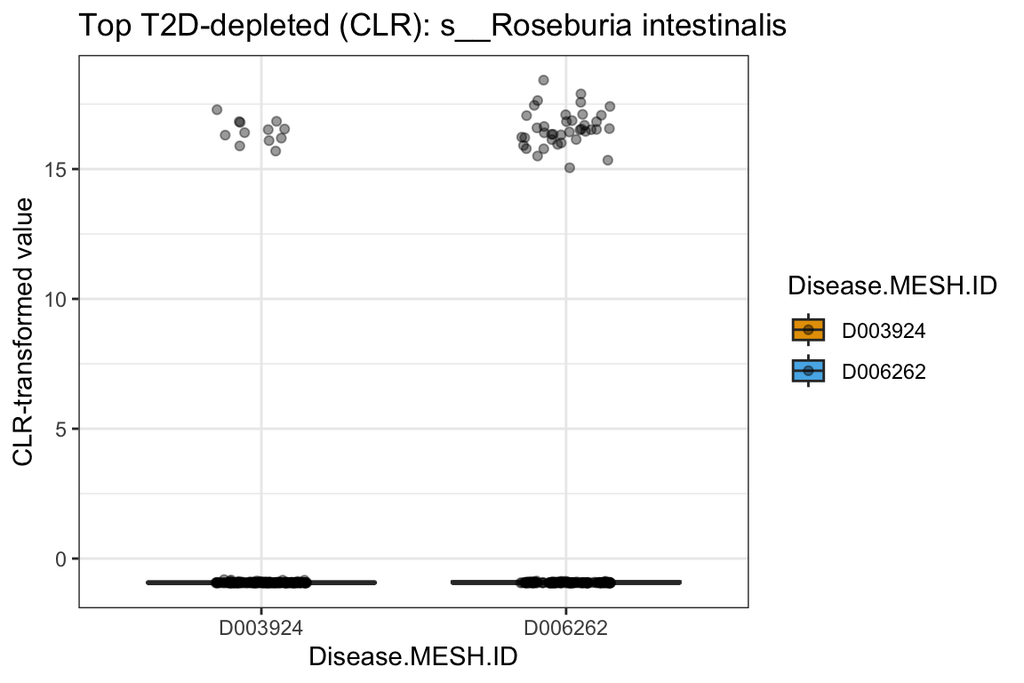

```r
top_taxon <- clr_T2D_depleted %>% slice(1) %>% pull(taxon)
top_label <- clr_T2D_depleted %>% slice(1) %>% pull(Species)

dat_clr %>%
  filter(taxon == top_taxon) %>%
  ggplot(aes(x = Disease.MESH.ID, y = clr, fill = Disease.MESH.ID)) +
    geom_boxplot(outlier.shape = NA) +
    geom_jitter(width = 0.15, alpha = 0.4) +
    scale_fill_manual(values = c("D003924" = "#E69F00", "D006262" = "#56B4E9")) +
    theme_bw() +
    labs(title = paste("Top T2D-depleted (CLR):", top_label),
         y = "CLR-transformed value")
```

> *Taught in: W21 reference Rmd §9 (boxplot of the top CLR hit on the CLR scale).*

### Top T2D-enriched (CLR)

```r
clr_T2D_enriched <- clr_disease_adjusted_sex_results %>%
  select(taxon, Genus, Species, estimate, std.error, statistic, p.value, q_value) %>%
  arrange(-estimate) %>%
  head(10)

clr_T2D_enriched
```

```
## # A tibble: 10 × 8
##    taxon  Genus             Species estimate std.error statistic p.value q_value
##    <chr>  <chr>             <chr>      <dbl>     <dbl>     <dbl>   <dbl>   <dbl>
##  1 208479 g__Enterocloster  s__Ent…    1.67      0.500      3.34 9.24e-4  0.0800
##  2 46503  g__Ruminococcus_B s__Rum…    1.51      0.753      2.00 4.64e-2  0.425
##  3 357276 g__Phocaeicola    s__Pho…    1.45      0.880      1.65 1.00e-1  0.592
##  4 39492  g__Ruminiclostri… s__Rum…    1.41      0.509      2.78 5.72e-3  0.274
##  5 216816 g__Bifidobacteri… s__Bif…    1.28      0.649      1.98 4.88e-2  0.425
##  6 246787 g__Bacteroides    s__Bac…    1.20      0.589      2.05 4.16e-2  0.425
##  7 47678  g__Bacteroides    s__Bac…    1.14      0.882      1.29 1.98e-1  0.710
##  8 239935 g__Akkermansia    s__Akk…    1.07      0.520      2.06 3.98e-2  0.425
##  9 40518  g__Ruminococcoid… s__Rum…    1.05      0.888      1.18 2.38e-1  0.710
## 10 28116  g__Bacteroides    s__Bac…    0.998     0.832      1.20 2.31e-1  0.710
```

> *Taught in: W21 reference Rmd §9 (CLR top table, enriched tail).*

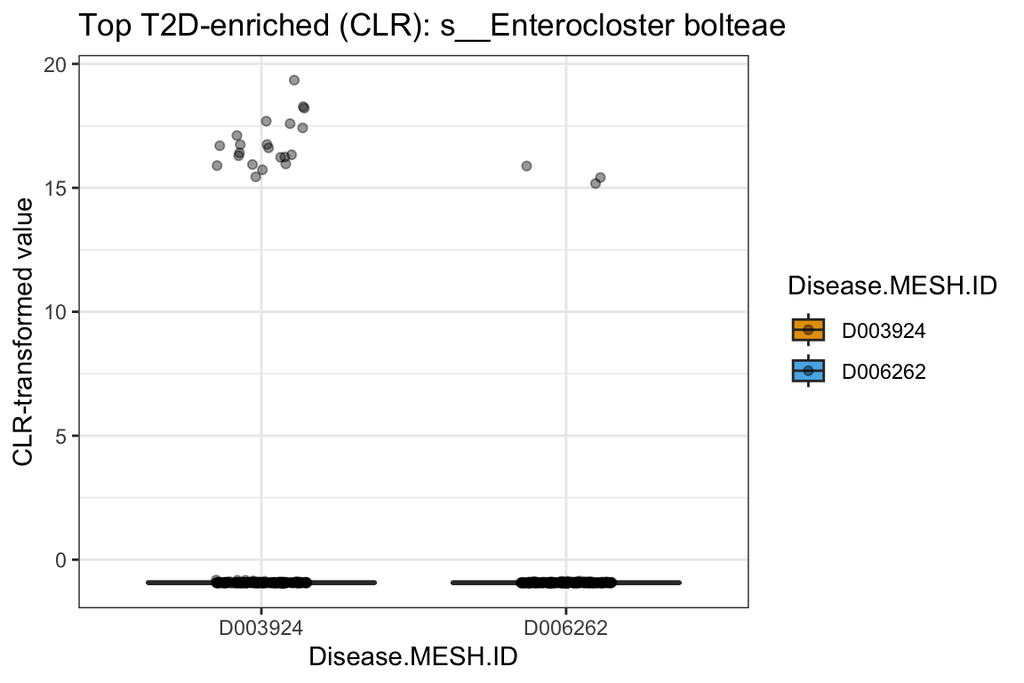

```r
top_taxon <- clr_T2D_enriched %>% slice(1) %>% pull(taxon)
top_label <- clr_T2D_enriched %>% slice(1) %>% pull(Species)

dat_clr %>%
  filter(taxon == top_taxon) %>%
  ggplot(aes(x = Disease.MESH.ID, y = clr, fill = Disease.MESH.ID)) +
    geom_boxplot(outlier.shape = NA) +
    geom_jitter(width = 0.15, alpha = 0.4) +
    scale_fill_manual(values = c("D003924" = "#E69F00", "D006262" = "#56B4E9")) +
    theme_bw() +
    labs(title = paste("Top T2D-enriched (CLR):", top_label),
         y = "CLR-transformed value")
```

> *Taught in: W21 reference Rmd §9 (boxplot of the top enriched CLR hit on the CLR scale).*

### Volcano plot — CLR

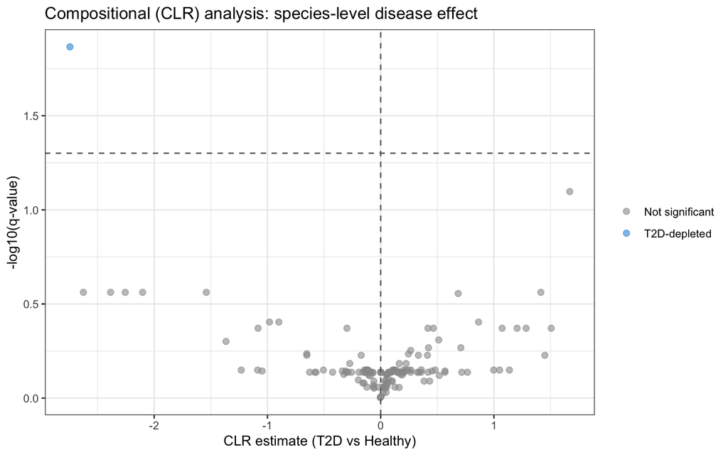

```r
clr_disease_adjusted_sex_results %>%
  mutate(
    neg_log10_q = -log10(q_value),
    direction = case_when(
      q_value < 0.05 & estimate > 0 ~ "T2D-enriched",
      q_value < 0.05 & estimate < 0 ~ "T2D-depleted",
      TRUE                          ~ "Not significant"
    )
  ) %>%
  ggplot(aes(x = estimate, y = neg_log10_q, color = direction)) +
    geom_point(alpha = 0.6, size = 2) +
    scale_color_manual(values = c("T2D-enriched" = "#E74C3C",
                                  "T2D-depleted" = "#3498DB",
                                  "Not significant" = "grey60")) +
    geom_hline(yintercept = -log10(0.05), linetype = "dashed", color = "grey40") +
    geom_vline(xintercept = 0, linetype = "dashed", color = "grey40") +
    labs(x = "CLR estimate (T2D vs Healthy)",
         y = "-log10(q-value)", color = NULL,
         title = "Compositional (CLR) analysis: species-level disease effect") +
    theme_bw()
```

> *Taught in: W21 reference Rmd §9 (CLR volcano plot — the compositionally aware reference analysis).*

### Bar chart — CLR top significant taxa by q-value

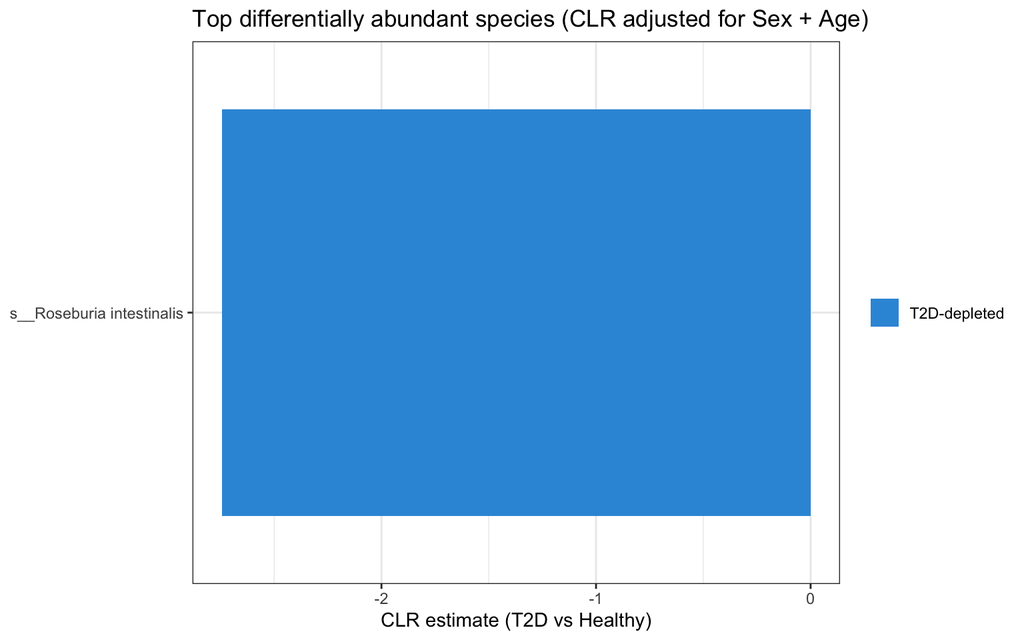

```r
bind_rows(
  clr_disease_adjusted_sex_results %>% filter(q_value < 0.05) %>% arrange(estimate)  %>% head(10),
  clr_disease_adjusted_sex_results %>% filter(q_value < 0.05) %>% arrange(-estimate) %>% head(10)
) %>%
  distinct() %>%
  mutate(
    label     = make.unique(as.character(Species), sep = "_"),
    direction = ifelse(estimate > 0, "T2D-enriched", "T2D-depleted")
  ) %>%
  ggplot(aes(x = reorder(label, -q_value), y = estimate, fill = direction)) +
    geom_col() +
    coord_flip() +
    scale_fill_manual(values = c("T2D-enriched" = "#E74C3C",
                                 "T2D-depleted" = "#3498DB")) +
    labs(x = NULL, y = "CLR estimate (T2D vs Healthy)", fill = NULL,
         title = "Top differentially abundant species (CLR adjusted for Sex + Age)") +
    theme_bw()
```

> *Taught in: W21 reference Rmd §9 (bar chart of top significant CLR taxa, top-10 each side, ordered by q-value).*

## Sensitivity analysis — adding BMI (n = 151)

```r
meta_check <- data.frame(sample_data(ps))
sensitivity_n <- meta_check %>%
  filter(!is.na(BMI), !is.na(Host.age), !is.na(Sex)) %>%
  nrow()
sensitivity_n
```

```
## [1] 151
```

> *Project-chosen step (not a separate taught method): counts samples with complete covariates, the precondition for the complete-case BMI model. Inspecting `sample_data` taught in W20-01.*

### GLM sensitivity — Sex + Host.age + BMI

```r
glm_disease_sensitivity_BMI <- dat_rel %>%
  mutate(
    Disease.MESH.ID = factor(Disease.MESH.ID, levels = c("D006262", "D003924")),
    Sex             = factor(Sex,             levels = c("Female", "Male")),
    Host.age        = as.numeric(Host.age),
    BMI             = as.numeric(BMI)
  ) %>%
  filter(!is.na(BMI)) %>%
  group_by(taxon, Genus, Species) %>%
  group_modify(~ {
    fit <- glm(log10(rel_abund + 1e-6) ~ Disease.MESH.ID + Sex + Host.age + BMI,
               data = .x, family = gaussian())
    broom::tidy(fit)
  }) %>%
  ungroup() %>%
  filter(term == "Disease.MESH.IDD003924") %>%
  mutate(
    q_value = p.adjust(p.value, method = "BH"),
    fold_change_T2D_vs_Healthy_BMI = 10^estimate
  )

glm_disease_sensitivity_BMI %>%
  select(taxon, Genus, Species, estimate, fold_change_T2D_vs_Healthy_BMI,
         std.error, statistic, p.value, q_value) %>%
  arrange(fold_change_T2D_vs_Healthy_BMI) %>%
  head(10)
```

```
## # A tibble: 10 × 9
##    taxon  Genus      Species estimate fold_change_T2D_vs_H…¹ std.error statistic
##    <chr>  <chr>      <chr>      <dbl>                  <dbl>     <dbl>     <dbl>
##  1 166486 g__Rosebu… s__Ros…   -1.10                  0.0798     0.327    -3.36
##  2 820    g__Bacter… s__Bac…   -1.02                  0.0951     0.497    -2.06
##  3 853    g__Faecal… s__Fae…   -0.816                 0.153      0.487    -1.68
##  4 387090 g__Phocae… s__Pho…   -0.682                 0.208      0.239    -2.86
##  5 729    g__Haemop… s__Hae…   -0.621                 0.239      0.202    -3.07
##  6 360807 g__Rosebu… s__Ros…   -0.508                 0.310      0.411    -1.24
##  7 457412 g__Blauti… s__Bla…   -0.476                 0.334      0.239    -1.99
##  8 818    g__Bacter… s__Bac…   -0.427                 0.374      0.442    -0.966
##  9 821    g__Phocae… s__Pho…   -0.407                 0.392      0.510    -0.798
## 10 411489 g__Coproc… s__Cop…   -0.393                 0.405      0.262    -1.50
## # ℹ abbreviated name: ¹fold_change_T2D_vs_Healthy_BMI
## # ℹ 2 more variables: p.value <dbl>, q_value <dbl>
```

> *Method taught in: W21 reference Rmd §7 (covariate-adjusted GLM) — identical model with BMI added. BMI is a **project-chosen** covariate run only as a sensitivity check (missing for 58% of samples), not part of the reference.*

### CLR sensitivity — Sex + Host.age + BMI

```r
clr_disease_sensitivity_BMI <- dat_clr %>%
  mutate(
    Disease.MESH.ID = factor(Disease.MESH.ID, levels = c("D006262", "D003924")),
    Sex             = factor(Sex,             levels = c("Female", "Male")),
    Host.age        = as.numeric(Host.age),
    BMI             = as.numeric(BMI)
  ) %>%
  filter(!is.na(BMI)) %>%
  group_by(taxon, Genus, Species) %>%
  group_modify(~ {
    fit <- lm(clr ~ Disease.MESH.ID + Sex + Host.age + BMI, data = .x)
    broom::tidy(fit)
  }) %>%
  ungroup() %>%
  filter(term == "Disease.MESH.IDD003924") %>%
  mutate(q_value = p.adjust(p.value, method = "BH"))

clr_disease_sensitivity_BMI %>%
  select(taxon, Genus, Species, estimate, std.error, statistic, p.value, q_value) %>%
  arrange(estimate) %>%
  head(10)
```

```
## # A tibble: 10 × 8
##    taxon  Genus             Species estimate std.error statistic p.value q_value
##    <chr>  <chr>             <chr>      <dbl>     <dbl>     <dbl>   <dbl>   <dbl>
##  1 166486 g__Roseburia      s__Ros…    -4.07     1.22     -3.35  0.00102   0.177
##  2 820    g__Bacteroides    s__Bac…    -3.62     1.81     -2.00  0.0473    0.902
##  3 853    g__Faecalibacter… s__Fae…    -2.92     1.76     -1.66  0.0987    0.902
##  4 387090 g__Phocaeicola    s__Pho…    -2.44     0.851    -2.87  0.00475   0.274
##  5 729    g__Haemophilus_D  s__Hae…    -2.31     0.752    -3.08  0.00251   0.217
##  6 360807 g__Roseburia      s__Ros…    -1.87     1.52     -1.23  0.222     0.902
##  7 457412 g__Blautia_A      s__Bla…    -1.76     0.892    -1.97  0.0509    0.902
##  8 818    g__Bacteroides    s__Bac…    -1.58     1.61     -0.980 0.329     0.902
##  9 411489 g__Coprococcus    s__Cop…    -1.51     0.961    -1.57  0.120     0.902
## 10 821    g__Phocaeicola    s__Pho…    -1.49     1.86     -0.802 0.424     0.902
```

> *Method taught in: W21 reference Rmd §9 (covariate-adjusted CLR linear model) — identical model with BMI added. BMI is a **project-chosen** sensitivity covariate, not part of the reference.*

### Primary vs BMI-sensitivity scatter (CLR)

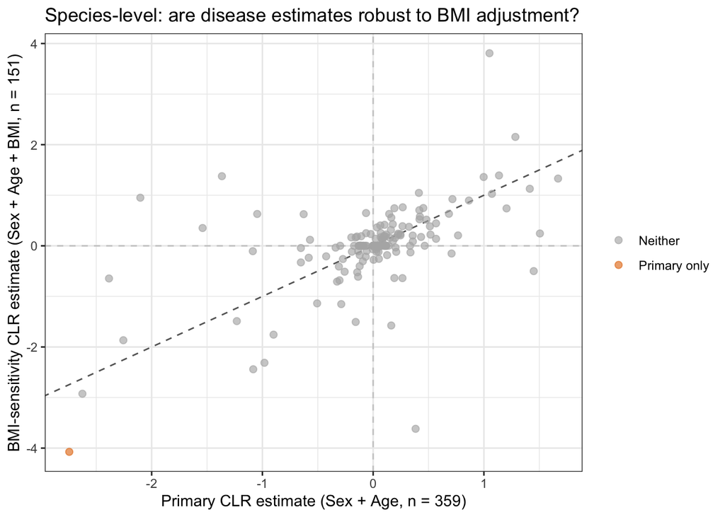

```r
clr_disease_adjusted_sex_results %>%
  select(taxon, primary_estimate = estimate, primary_q = q_value) %>%
  inner_join(
    clr_disease_sensitivity_BMI %>%
      select(taxon, BMI_estimate = estimate, BMI_q = q_value),
    by = "taxon"
  ) %>%
  mutate(
    category = case_when(
      primary_q < 0.05 & BMI_q < 0.05 ~ "Significant in both",
      primary_q < 0.05                ~ "Primary only",
      BMI_q < 0.05                    ~ "BMI-sensitivity only",
      TRUE                            ~ "Neither"
    )
  ) %>%
  ggplot(aes(x = primary_estimate, y = BMI_estimate, color = category)) +
    geom_abline(slope = 1, intercept = 0, linetype = "dashed", color = "grey40") +
    geom_hline(yintercept = 0, linetype = "dashed", color = "grey80") +
    geom_vline(xintercept = 0, linetype = "dashed", color = "grey80") +
    geom_point(alpha = 0.65, size = 2) +
    scale_color_manual(values = c(
      "Significant in both"  = "#2E8B57",
      "Primary only"         = "#E67E22",
      "BMI-sensitivity only" = "#3498DB",
      "Neither"              = "grey70"
    )) +
    labs(x = "Primary CLR estimate (Sex + Age, n = 359)",
         y = "BMI-sensitivity CLR estimate (Sex + Age + BMI, n = 151)",
         color = NULL,
         title = "Species-level: are disease estimates robust to BMI adjustment?") +
    theme_bw()
```

> *Plot technique taught in: W21 reference Rmd §10 (effect-size scatter of two models against the identity line). Comparing primary vs BMI-sensitivity is a project-chosen application of that technique.*

## Compare differential abundance methods

```r
comparison_results <- wilcox_results %>%
  select(taxon, Genus, Species,
         wilcox_log2fc = log2_fc,
         wilcox_q = q_value) %>%
  left_join(
    glm_disease_results %>%
      select(taxon, glm_estimate = estimate, glm_q = q_value),
    by = "taxon"
  ) %>%
  left_join(
    glm_disease_adjusted_sex_results %>%
      select(taxon, glm_adj_estimate = estimate, glm_adj_q = q_value),
    by = "taxon"
  ) %>%
  left_join(
    clr_disease_adjusted_sex_results %>%
      select(taxon, clr_estimate = estimate, clr_q = q_value),
    by = "taxon"
  )
```

> *Taught in: W21 reference Rmd §10 “Compare differential abundance methods” (the hidden chunk joining all methods’ estimates + q-values into `comparison_results`).*

### Significant taxa per method

```r
sig_summary <- tibble(
  method = c(
    "Wilcoxon (n=359)",
    "GLM unadjusted (n=359)",
    "GLM adj. Sex+Age (n=359)",
    "GLM adj. Sex+Age+BMI (n=151)",
    "CLR adj. Sex+Age (n=359)",
    "CLR adj. Sex+Age+BMI (n=151)"
  ),
  n_significant = c(
    sum(wilcox_results$q_value < 0.05, na.rm = TRUE),
    sum(glm_disease_results$q_value < 0.05, na.rm = TRUE),
    sum(glm_disease_adjusted_sex_results$q_value < 0.05, na.rm = TRUE),
    sum(glm_disease_sensitivity_BMI$q_value < 0.05, na.rm = TRUE),
    sum(clr_disease_adjusted_sex_results$q_value < 0.05, na.rm = TRUE),
    sum(clr_disease_sensitivity_BMI$q_value < 0.05, na.rm = TRUE)
  )
)

sig_summary
```

```
## # A tibble: 6 × 2
##   method                       n_significant
##   <chr>                                <int>
## 1 Wilcoxon (n=359)                         5
## 2 GLM unadjusted (n=359)                   5
## 3 GLM adj. Sex+Age (n=359)                 1
## 4 GLM adj. Sex+Age+BMI (n=151)             0
## 5 CLR adj. Sex+Age (n=359)                 1
## 6 CLR adj. Sex+Age+BMI (n=151)             0
```

> *Taught in: W21 reference Rmd §10 (count of significant taxa per method at q < 0.05). The reference has 4 rows; the two BMI-sensitivity rows are project additions reporting the same count for the sensitivity models.*

### Taxa significant in all four primary methods

```r
all_methods_sig <- comparison_results %>%
  filter(wilcox_q < 0.05, glm_q < 0.05, glm_adj_q < 0.05, clr_q < 0.05) %>%
  select(Genus, Species, wilcox_q, glm_q, glm_adj_q, clr_q) %>%
  arrange(wilcox_q)

all_methods_sig
```

```
## # A tibble: 1 × 6
##   Genus        Species                   wilcox_q   glm_q glm_adj_q  clr_q
##   <chr>        <chr>                        <dbl>   <dbl>     <dbl>  <dbl>
## 1 g__Roseburia s__Roseburia intestinalis  0.00159 0.00135    0.0134 0.0136
```

> *Taught in: W21 reference Rmd §10 (taxa significant in all four methods = consensus candidates).*

### Effect-size comparison — GLM unadjusted vs GLM adjusted

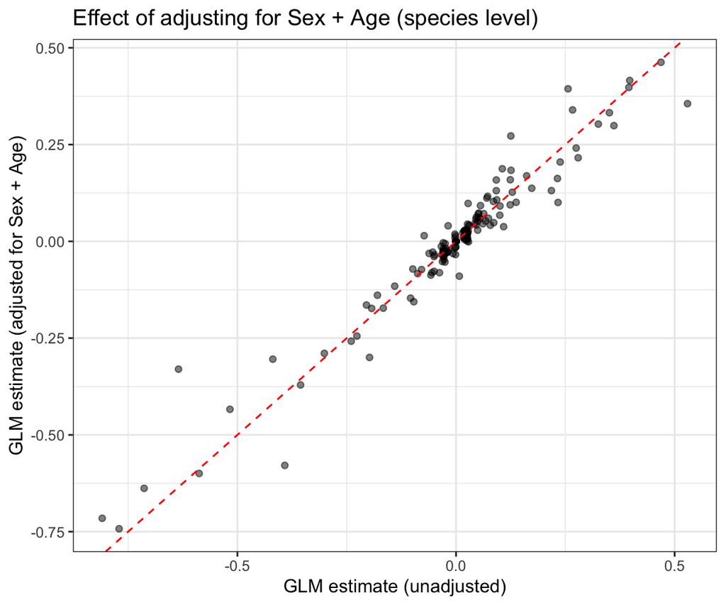

```r
comparison_results %>%
  ggplot(aes(x = glm_estimate, y = glm_adj_estimate)) +
    geom_point(alpha = 0.5) +
    geom_abline(slope = 1, intercept = 0, linetype = "dashed", color = "red") +
    labs(x = "GLM estimate (unadjusted)",
         y = "GLM estimate (adjusted for Sex + Age)",
         title = "Effect of adjusting for Sex + Age (species level)") +
    theme_bw()
```

> *Taught in: W21 reference Rmd §10 (effect-size scatter of unadjusted vs adjusted GLM against the y = x diagonal; points off the diagonal are taxa whose disease estimate changes after covariate adjustment).*

### Effect-size comparison — GLM adjusted vs CLR

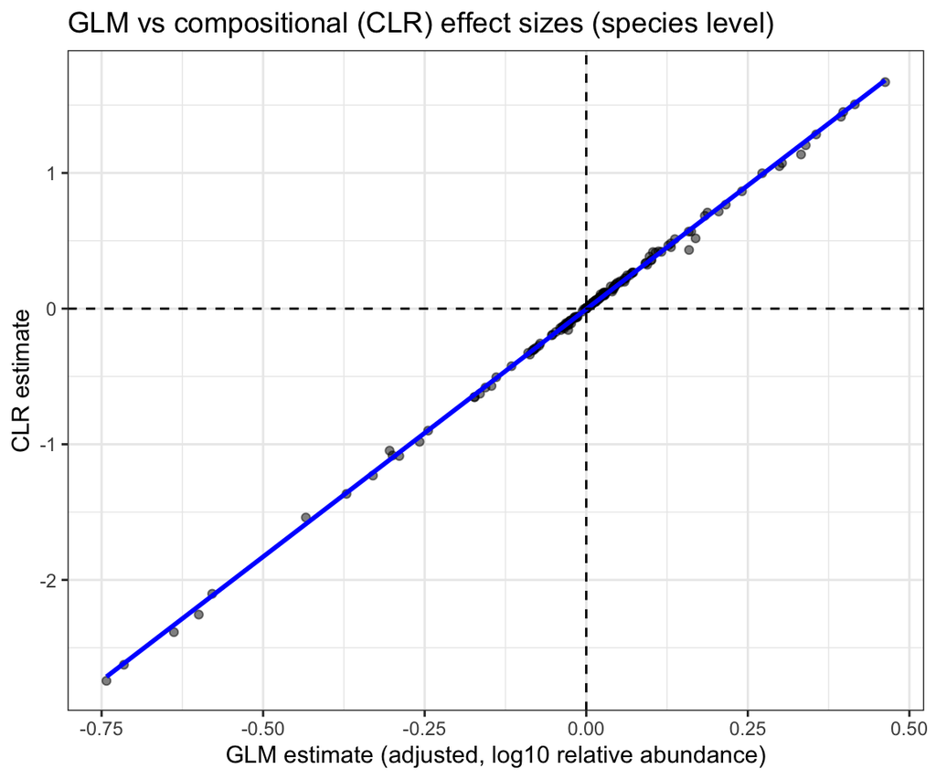

```r
comparison_results %>%
  ggplot(aes(x = glm_adj_estimate, y = clr_estimate)) +
    geom_point(alpha = 0.5) +
    geom_smooth(method = "lm", se = FALSE, color = "blue") +
    geom_hline(yintercept = 0, linetype = "dashed") +
    geom_vline(xintercept = 0, linetype = "dashed") +
    labs(x = "GLM estimate (adjusted, log10 relative abundance)",
         y = "CLR estimate",
         title = "GLM vs compositional (CLR) effect sizes (species level)") +
    theme_bw()
```

> *Taught in: W21 reference Rmd §10 (scatter comparing GLM-adjusted and CLR effect sizes; outliers are taxa whose inferred effect is most changed by compositional correction).*

### Concordance across methods

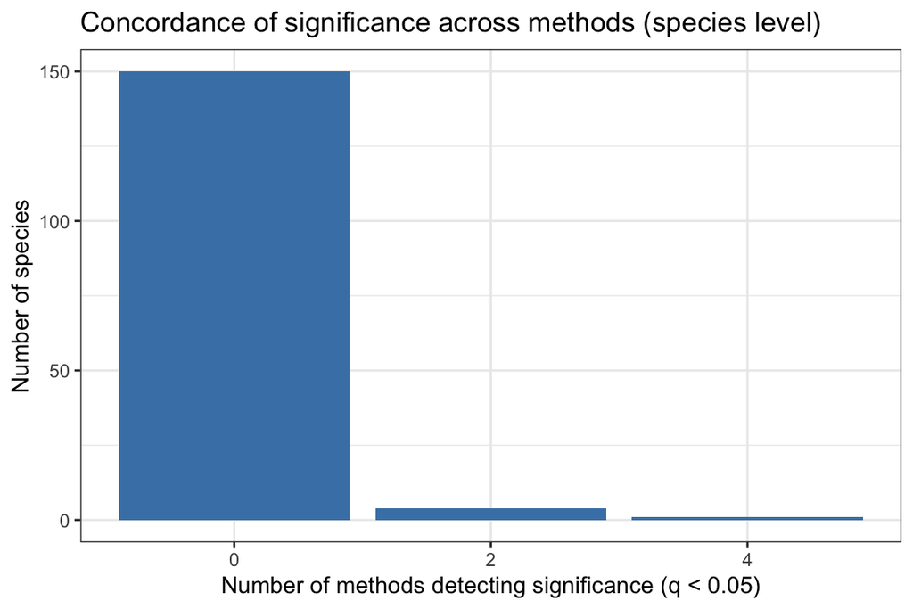

```r
comparison_results %>%
  mutate(
    sig_wilcox  = wilcox_q  < 0.05,
    sig_glm     = glm_q     < 0.05,
    sig_glm_adj = glm_adj_q < 0.05,
    sig_clr     = clr_q     < 0.05,
    n_methods_significant = sig_wilcox + sig_glm + sig_glm_adj + sig_clr
  ) %>%
  count(n_methods_significant) %>%
  filter(!is.na(n_methods_significant)) %>%
  ggplot(aes(x = factor(n_methods_significant), y = n)) +
    geom_col(fill = "steelblue") +
    labs(x = "Number of methods detecting significance (q < 0.05)",
         y = "Number of species",
         title = "Concordance of significance across methods (species level)") +
    theme_bw()
```

> *Taught in: W21 reference Rmd §10 (bar chart counting how many methods support each taxon).*

### Significance × direction heatmap

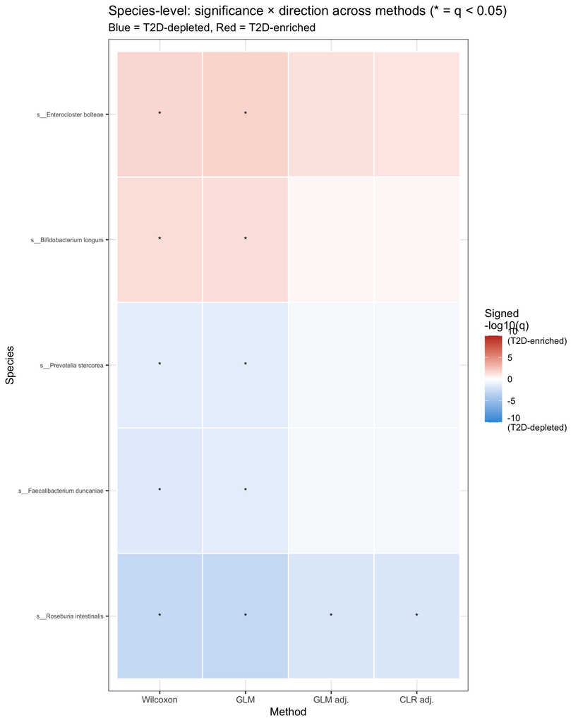

```r
heatmap_data <- comparison_results %>%
  filter(wilcox_q < 0.05 | glm_q < 0.05 | glm_adj_q < 0.05 | clr_q < 0.05) %>%
  mutate(label = make.unique(as.character(Species), sep = "_")) %>%
  select(label,
         wilcox_q, glm_q, glm_adj_q, clr_q,
         wilcox_log2fc, glm_estimate, glm_adj_estimate, clr_estimate) %>%
  pivot_longer(cols = c(wilcox_q, glm_q, glm_adj_q, clr_q),
               names_to = "method", values_to = "q_value") %>%
  mutate(
    direction = case_when(
      method == "wilcox_q"  ~ wilcox_log2fc,
      method == "glm_q"     ~ glm_estimate,
      method == "glm_adj_q" ~ glm_adj_estimate,
      method == "clr_q"     ~ clr_estimate
    ),
    signed_neg_log10_q = sign(direction) * pmin(-log10(q_value), 10),
    method = factor(method,
                    levels = c("wilcox_q", "glm_q", "glm_adj_q", "clr_q"),
                    labels = c("Wilcoxon", "GLM", "GLM adj.", "CLR adj."))
  )

taxon_order <- heatmap_data %>%
  group_by(label) %>%
  summarise(mean_signed = mean(signed_neg_log10_q, na.rm = TRUE), .groups = "drop") %>%
  arrange(mean_signed) %>%
  pull(label)

heatmap_data %>%
  mutate(label = factor(label, levels = taxon_order)) %>%
  ggplot(aes(x = method, y = label, fill = signed_neg_log10_q)) +
    geom_tile(color = "white", linewidth = 0.5) +
    geom_text(aes(label = ifelse(q_value < 0.05, "*", "")),
              color = "black", size = 3) +
    scale_fill_gradient2(
      low = "#3498DB", mid = "white", high = "#C0392B",
      midpoint = 0, limits = c(-10, 10),
      name = "Signed\n-log10(q)",
      breaks = c(-10, -5, 0, 5, 10),
      labels = c("-10\n(T2D-depleted)", "-5", "0", "5", "10\n(T2D-enriched)")
    ) +
    labs(x = "Method", y = "Species",
         title = "Species-level: significance × direction across methods (* = q < 0.05)",
         subtitle = "Blue = T2D-depleted, Red = T2D-enriched") +
    theme_bw() +
    theme(axis.text.y = element_text(size = 6))
```

> *Taught in: W21 reference Rmd §10 (signed `-log10(q)` heatmap across methods for taxa significant in ≥1 method; `*` marks q < 0.05, `scale_fill_gradient2` encodes direction).*

### Effect-size agreement — Wilcoxon vs CLR

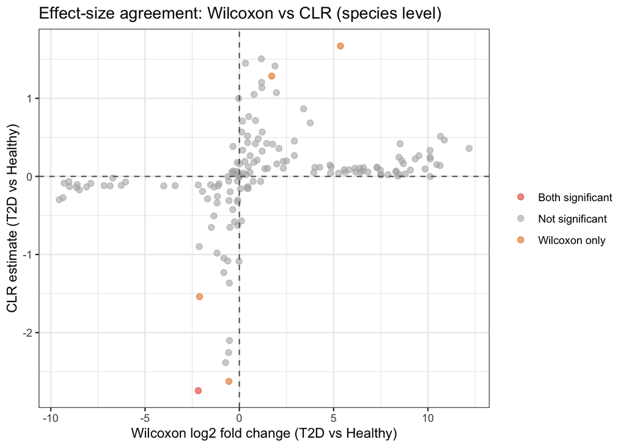

```r
comparison_results %>%
  mutate(
    sig_category = case_when(
      wilcox_q < 0.05 & clr_q < 0.05 ~ "Both significant",
      wilcox_q < 0.05                ~ "Wilcoxon only",
      clr_q < 0.05                   ~ "CLR only",
      TRUE                           ~ "Not significant"
    )
  ) %>%
  ggplot(aes(x = wilcox_log2fc, y = clr_estimate, color = sig_category)) +
    geom_point(alpha = 0.6, size = 2) +
    scale_color_manual(values = c(
      "Both significant" = "#E74C3C",
      "Wilcoxon only"    = "#E67E22",
      "CLR only"         = "#3498DB",
      "Not significant"  = "grey70"
    )) +
    geom_hline(yintercept = 0, linetype = "dashed", color = "grey40") +
    geom_vline(xintercept = 0, linetype = "dashed", color = "grey40") +
    labs(x = "Wilcoxon log2 fold change (T2D vs Healthy)",
         y = "CLR estimate (T2D vs Healthy)",
         color = NULL,
         title = "Effect-size agreement: Wilcoxon vs CLR (species level)") +
    theme_bw()
```

> *Taught in: W21 reference Rmd §10 (final method-comparison scatter — same-sign points indicate agreement between the simplest rank-based and the compositionally aware univariate method).*

# Multivariate statistics

## PCA of CLR-transformed species profiles

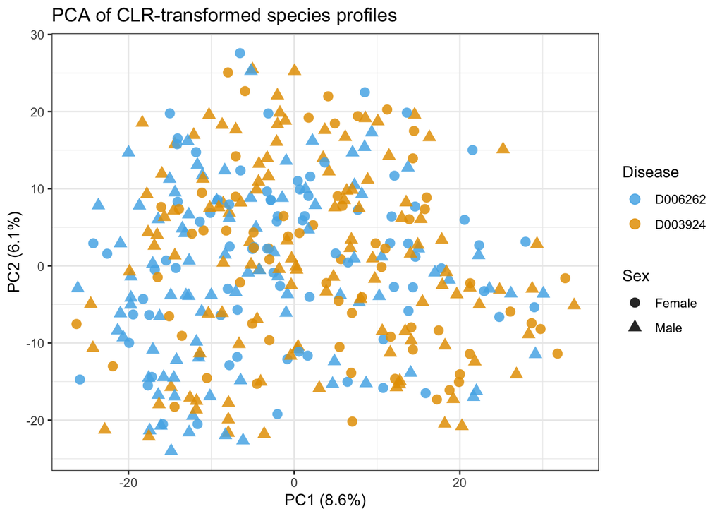

```r
clr_mat  <- otu_clr %>% as.matrix()
meta_pca <- meta_clr[rownames(clr_mat), ]
# Base-R coercion preserves rownames (dplyr::mutate would drop them):
meta_pca$Disease.MESH.ID <- factor(meta_pca$Disease.MESH.ID,
                                   levels = c("D006262", "D003924"))
meta_pca$Sex             <- factor(meta_pca$Sex, levels = c("Female", "Male"))
meta_pca$Host.age        <- as.numeric(meta_pca$Host.age)

clr_pca <- prcomp(clr_mat, center = TRUE, scale. = FALSE)

pca_scores <- as.data.frame(clr_pca$x[, 1:2]) %>%
  rownames_to_column("sample_id") %>%
  left_join(meta_pca %>% rownames_to_column("sample_id"), by = "sample_id")

pca_var <- round(100 * clr_pca$sdev^2 / sum(clr_pca$sdev^2), 1)

pca_scores %>%
  ggplot(aes(x = PC1, y = PC2, color = Disease.MESH.ID, shape = Sex)) +
    geom_point(size = 3, alpha = 0.85) +
    scale_color_manual(values = c("D003924" = "#E69F00", "D006262" = "#56B4E9")) +
    scale_shape_manual(values = c("Female" = 16, "Male" = 17)) +
    labs(x = paste0("PC1 (", pca_var[1], "%)"),
         y = paste0("PC2 (", pca_var[2], "%)"),
         color = "Disease", shape = "Sex",
         title = "PCA of CLR-transformed species profiles") +
    theme_bw()
```

> *Taught in: W21 reference Rmd §11 “PCA of CLR-transformed gut profiles” (`prcomp` on the CLR matrix, PC1/PC2 coloured by group, `% variance` from `sdev^2`). Ordination of CLR/Aitchison data also W20-03; whole-community structure Alberdi reading §8.*

## Constrained ordination with RDA

```r
# Drop any samples missing a constraint variable (RDA requires complete cases on predictors)
rda_keep   <- complete.cases(meta_pca[, c("Disease.MESH.ID", "Sex", "Host.age")])
clr_mat_rda <- clr_mat[rda_keep, ]
meta_rda    <- meta_pca[rda_keep, ]

rda_disease <- rda(clr_mat_rda ~ Disease.MESH.ID + Sex + Host.age, data = meta_rda)
```

> *Taught in: W21 reference Rmd §12 “Constrained ordination with RDA” (`rda(clr_mat ~ predictors)`; reference constrains by `age + status`). Here the constraint mirrors the primary adjusted univariate model — `Disease.MESH.ID + Sex + Host.age` — so the multivariate test partitions community variance against the same covariates that the per-taxon CLR model adjusts for. Constrained ordination: Alberdi reading §8.*

```r
anova(rda_disease, permutations = 999)
```

```
## Permutation test for rda under reduced model
## Permutation: free
## Number of permutations: 999
##
## Model: rda(formula = clr_mat_rda ~ Disease.MESH.ID + Sex + Host.age, data = meta_rda)
##           Df Variance      F Pr(>F)
## Model      3    35.39 1.9501  0.001 ***
## Residual 355  2147.20
## ---
## Signif. codes:  0 '***' 0.001 '**' 0.01 '*' 0.05 '.' 0.1 ' ' 1
```

```r
anova(rda_disease, by = "term", permutations = 999)
```

```
## Permutation test for rda under reduced model
## Terms added sequentially (first to last)
## Permutation: free
## Number of permutations: 999
##
## Model: rda(formula = clr_mat_rda ~ Disease.MESH.ID + Sex + Host.age, data = meta_rda)
##                  Df Variance      F Pr(>F)
## Disease.MESH.ID   1    18.90 3.1254  0.001 ***
## Sex               1     9.19 1.5195  0.026 *
## Host.age          1     7.29 1.2054  0.173
## Residual        355  2147.20
## ---
## Signif. codes:  0 '***' 0.001 '**' 0.01 '*' 0.05 '.' 0.1 ' ' 1
```

> *Taught in: W21 reference Rmd §12 (`anova(rda, permutations = 999)` whole-model and `by = "term"` per-predictor permutation tests). Permutation testing of ordination also relates to PERMANOVA `adonis2` in W20-03.*

```r
rda_site_scores_raw <- scores(rda_disease, display = "sites")
rda1_sign <- ifelse(
  mean(rda_site_scores_raw[meta_rda$Disease.MESH.ID == "D003924", "RDA1"], na.rm = TRUE) >=
    mean(rda_site_scores_raw[meta_rda$Disease.MESH.ID == "D006262", "RDA1"], na.rm = TRUE),
  1, -1
)

taxon_scores <- scores(rda_disease, display = "species")[, 1] * rda1_sign

rda_taxa <- tibble(
  taxon        = names(taxon_scores),
  rda1_loading = taxon_scores
) %>%
  arrange(desc(abs(rda1_loading)))
```

> *Taught in: W21 reference Rmd §12 (extract RDA1 taxon scores via `scores(..., display = "species")`, sign-orient RDA1 by group means, rank by absolute loading).*

### RDA biplot

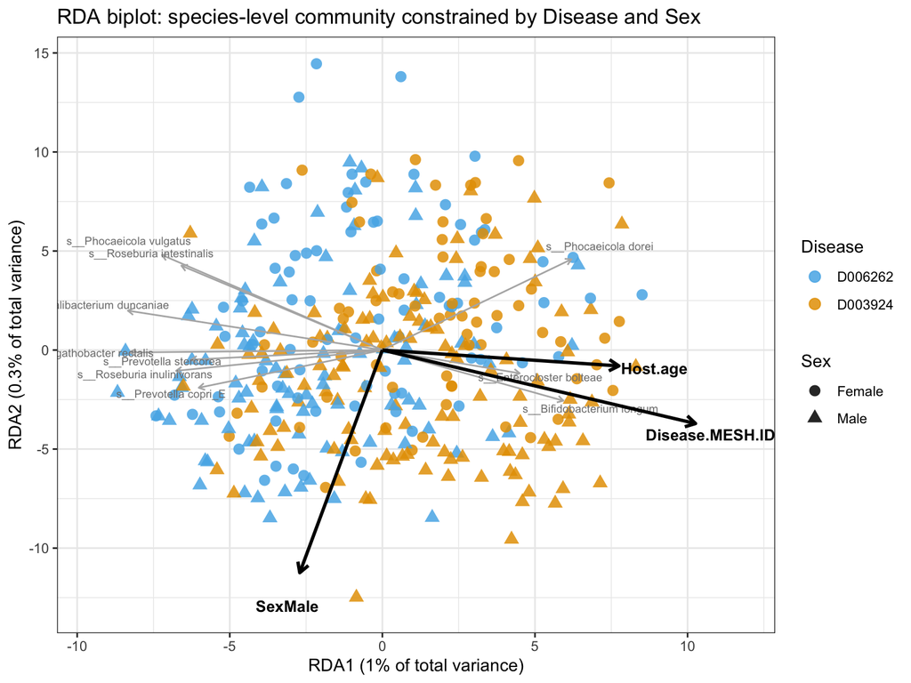

```r
eig <- rda_disease$CCA$eig
pct1 <- round(eig[1] / rda_disease$tot.chi * 100, 1)
pct2 <- round(eig[2] / rda_disease$tot.chi * 100, 1)

site_scores <- scores(rda_disease, display = "sites") %>%
  as.data.frame() %>%
  mutate(RDA1 = RDA1 * rda1_sign) %>%
  rownames_to_column("sample_id") %>%
  left_join(meta_rda %>% rownames_to_column("sample_id"), by = "sample_id")

biplot_scores <- scores(rda_disease, display = "bp") %>%
  as.data.frame() %>%
  mutate(RDA1 = RDA1 * rda1_sign) %>%
  rownames_to_column("variable")

top_species_scores <- scores(rda_disease, display = "species") %>%
  as.data.frame() %>%
  mutate(RDA1 = RDA1 * rda1_sign) %>%
  rownames_to_column("taxon") %>%
  inner_join(rda_taxa %>% head(10), by = "taxon") %>%
  left_join(tax_clr %>% rownames_to_column("taxon"), by = "taxon") %>%
  mutate(label = make.unique(as.character(Species), sep = "_"))

site_range    <- max(abs(c(site_scores$RDA1, site_scores$RDA2)))
arrow_scale   <- site_range * 0.8 / max(sqrt(biplot_scores$RDA1^2 + biplot_scores$RDA2^2))
species_scale <- site_range * 0.6 / max(sqrt(top_species_scores$RDA1^2 + top_species_scores$RDA2^2))

biplot_scores      <- biplot_scores      %>% mutate(RDA1 = RDA1 * arrow_scale,   RDA2 = RDA2 * arrow_scale)
top_species_scores <- top_species_scores %>% mutate(RDA1 = RDA1 * species_scale, RDA2 = RDA2 * species_scale)

ggplot() +
  geom_point(data = site_scores,
             aes(x = RDA1, y = RDA2, color = Disease.MESH.ID, shape = Sex),
             size = 3, alpha = 0.85) +
  geom_segment(data = top_species_scores,
               aes(x = 0, y = 0, xend = RDA1, yend = RDA2),
               arrow = arrow(length = unit(0.15, "cm")),
               color = "grey70", linewidth = 0.5) +
  geom_text(data = top_species_scores,
            aes(x = RDA1 * 1.15, y = RDA2 * 1.15, label = label),
            size = 2.5, color = "grey50") +
  geom_segment(data = biplot_scores,
               aes(x = 0, y = 0, xend = RDA1, yend = RDA2),
               arrow = arrow(length = unit(0.25, "cm")),
               color = "black", linewidth = 1) +
  geom_text(data = biplot_scores,
            aes(x = RDA1 * 1.15, y = RDA2 * 1.15, label = variable),
            size = 3.5, fontface = "bold", color = "black") +
  scale_color_manual(values = c("D003924" = "#E69F00", "D006262" = "#56B4E9")) +
  scale_shape_manual(values = c("Female" = 16, "Male" = 17)) +
  labs(x = paste0("RDA1 (", pct1, "% of total variance)"),
       y = paste0("RDA2 (", pct2, "% of total variance)"),
       color = "Disease", shape = "Sex",
       title = "RDA biplot: species-level community constrained by Disease and Sex") +
  theme_bw()
```

> *Taught in: W21 reference Rmd §12 (RDA biplot overlaying site scores, constraint arrows (`display = "bp"`) and top-species arrows, with the same ~80%/60% arrow rescaling).*

### Top 20 species by RDA1 loading

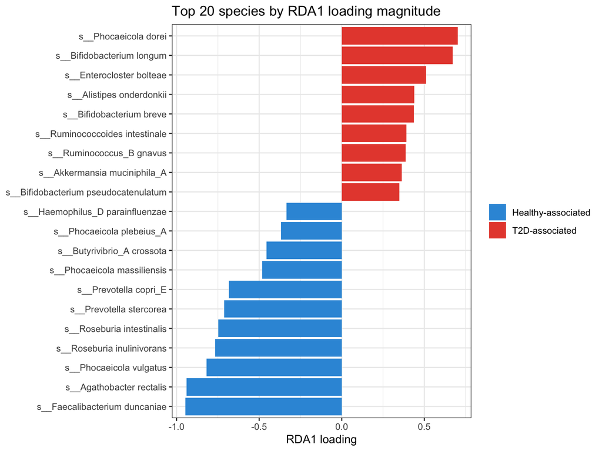

```r
rda_taxa %>%
  head(20) %>%
  left_join(tax_clr %>% rownames_to_column("taxon"), by = "taxon") %>%
  mutate(
    label     = make.unique(as.character(Species), sep = "_"),
    direction = ifelse(rda1_loading > 0, "T2D-associated", "Healthy-associated")
  ) %>%
  ggplot(aes(x = reorder(label, rda1_loading), y = rda1_loading, fill = direction)) +
    geom_col() +
    coord_flip() +
    scale_fill_manual(values = c("T2D-associated"     = "#E74C3C",
                                 "Healthy-associated" = "#3498DB")) +
    labs(x = NULL, y = "RDA1 loading", fill = NULL,
         title = "Top 20 species by RDA1 loading magnitude") +
    theme_bw()
```

> *Taught in: W21 reference Rmd §12 (bar chart of the top 20 taxa by RDA1 loading, coloured by group side).*

### RDA loadings vs CLR univariate estimates

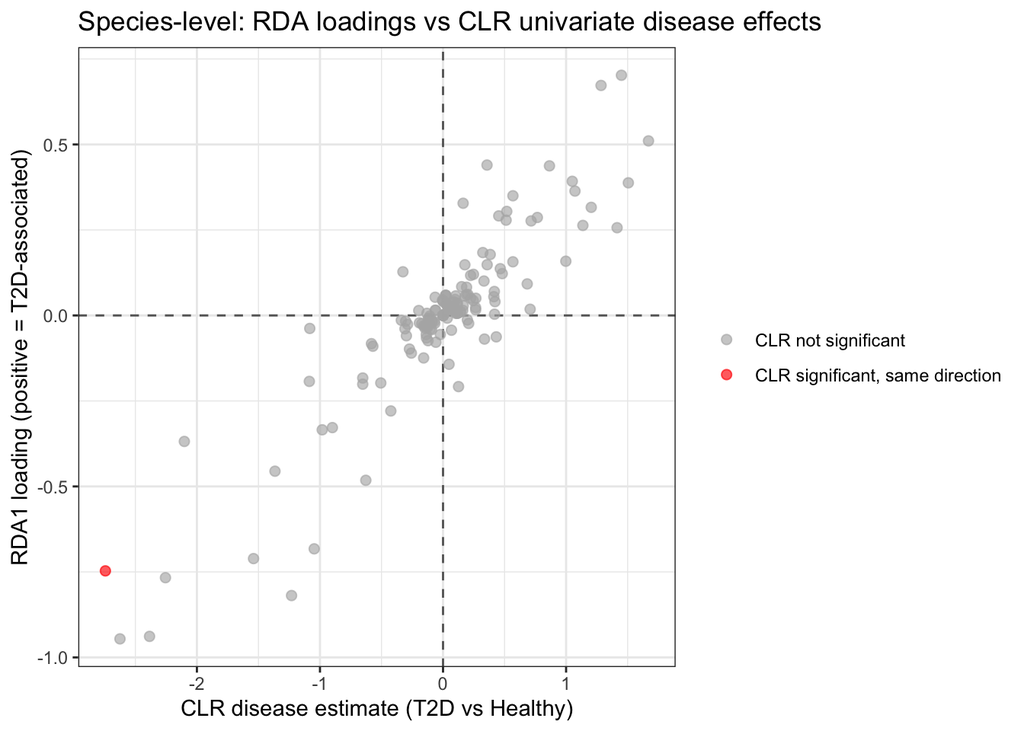

```r
rda_clr_comparison <- rda_taxa %>%
  left_join(
    clr_disease_adjusted_sex_results %>%
      select(taxon, Genus, Species,
             clr_estimate = estimate,
             clr_q = q_value),
    by = "taxon"
  ) %>%
  mutate(
    direction_agreement = sign(rda1_loading) == sign(clr_estimate),
    clr_result = case_when(
      clr_q < 0.05 & direction_agreement ~ "CLR significant, same direction",
      clr_q < 0.05                       ~ "CLR significant, opposite direction",
      TRUE                               ~ "CLR not significant"
    )
  )

rda_clr_comparison %>%
  ggplot(aes(x = clr_estimate, y = rda1_loading, color = clr_result)) +
    geom_hline(yintercept = 0, linetype = "dashed", color = "grey40") +
    geom_vline(xintercept = 0, linetype = "dashed", color = "grey40") +
    geom_point(alpha = 0.65, size = 2) +
    scale_color_manual(values = c(
      "CLR significant, same direction"     = "red",
      "CLR significant, opposite direction" = "blue",
      "CLR not significant"                 = "grey70"
    )) +
    labs(x = "CLR disease estimate (T2D vs Healthy)",
         y = "RDA1 loading (positive = T2D-associated)",
         color = NULL,
         title = "Species-level: RDA loadings vs CLR univariate disease effects") +
    theme_bw()
```

> *Taught in: W21 reference Rmd §12 (scatter linking RDA1 loadings to univariate CLR estimates, coloured by significance + direction agreement).*

### Top 20 RDA loading species with their CLR statistics

```r
rda_clr_comparison %>%
  arrange(desc(abs(rda1_loading))) %>%
  select(Genus, Species, rda1_loading, clr_estimate, clr_q, direction_agreement) %>%
  head(20)
```

```
## # A tibble: 20 × 6
##    Genus            Species rda1_loading clr_estimate  clr_q direction_agreement
##    <chr>            <chr>          <dbl>        <dbl>  <dbl> <lgl>
##  1 g__Faecalibacte… s__Fae…       -0.946       -2.63  0.274  TRUE
##  2 g__Agathobacter  s__Aga…       -0.938       -2.38  0.274  TRUE
##  3 g__Phocaeicola   s__Pho…       -0.819       -1.23  0.710  TRUE
##  4 g__Roseburia     s__Ros…       -0.767       -2.26  0.274  TRUE
##  5 g__Roseburia     s__Ros…       -0.747       -2.74  0.0136 TRUE
##  6 g__Prevotella    s__Pre…       -0.711       -1.54  0.274  TRUE
##  7 g__Phocaeicola   s__Pho…        0.702        1.45  0.592  TRUE
##  8 g__Prevotella    s__Pre…       -0.682       -1.05  0.718  TRUE
##  9 g__Bifidobacter… s__Bif…        0.673        1.28  0.425  TRUE
## 10 g__Enterocloster s__Ent…        0.510        1.67  0.0800 TRUE
## 11 g__Phocaeicola   s__Pho…       -0.482       -0.628 0.729  TRUE
## 12 g__Butyrivibrio… s__But…       -0.455       -1.37  0.500  TRUE
## 13 g__Alistipes     s__Ali…        0.440        0.357 0.729  TRUE
## 14 g__Bifidobacter… s__Bif…        0.437        0.865 0.395  TRUE
## 15 g__Ruminococcoi… s__Rum…        0.392        1.05  0.710  TRUE
## 16 g__Ruminococcus… s__Rum…        0.388        1.51  0.425  TRUE
## 17 g__Phocaeicola   s__Pho…       -0.368       -2.10  0.274  TRUE
## 18 g__Akkermansia   s__Akk…        0.364        1.07  0.425  TRUE
## 19 g__Bifidobacter… s__Bif…        0.350        0.568 0.718  TRUE
## 20 g__Haemophilus_D s__Hae…       -0.334       -0.982 0.395  TRUE
```

> *Taught in: W21 reference Rmd §12 (final table of the top 20 RDA-loading taxa with CLR estimate, q-value and direction agreement).*

# Species-vs-genus comparison guidance

For the report, the most informative comparisons to make when both Rmds have been knit:

1. **`sig_summary` side by side.** Same six rows in each Rmd. Higher numbers at species level reflect finer resolution; lower numbers can reflect sparsity-driven power loss. Either pattern is interpretable.
2. **The CLR primary heatmap.** The genus-level heatmap shows ~30 rows; the species-level heatmap shows the species *within* those genera. Where a single genus row at genus level becomes multiple species rows at species level, the species version tells you which member is driving the signal — the headline biological finding.
3. **The BMI-sensitivity scatter.** Compare which hits survive BMI adjustment at both levels. Hits surviving at both levels are the most robust candidates for the metabolic story.
4. **The RDA biplot.** Species-level arrows are more specific (named at species rank where possible). Compare arrow direction with the genus-level biplot — if a *Faecalibacterium* arrow points Healthy at genus level, the species-level biplot should show *F. prausnitzii*-specific or *F.* sp.-specific arrows aligned in the same direction. If they don’t align, the genus-level signal was diluted by within-genus species heterogeneity — itself a biologically meaningful finding.

## Caveat: many “species” rows are not resolved to species

**Consequence:** a significant `s__Bacteroidaceae` or `s__unclassified Lachnospiraceae` row cannot be mapped to a specific metabolic function, because the bin contains organisms with different functional profiles. The metabolic interpretation (see `synthesis.Rmd`) is therefore restricted to taxa resolved to a real species or to a functionally coherent genus; unresolved family-level rows are reported as differential but **not** assigned a metabolic guild. This is also part of why genus-level results are treated as the more reliable backbone (per the teacher’s guidance): at genus level these same organisms aggregate into one interpretable row instead of being scattered across unresolved species-level bins.

> *Interpretation/limitation note — not a course method. Flags that the `s__`-prefixed labels are rank-mixed (a property of this MetaPhlAn reference object), which bounds what can be claimed functionally at species level.*